# ANCOVA in Vocabulary not taught (Vocabulary not taught)

Geiser C. Challco geiser@alumni.usp.br

- Setting Initial Variables
- Descriptive Statistics of Initial Data
- ANCOVA and Pairwise for one factor: **grupo**
  - Without remove non-normal data
  - Computing ANCOVA and PairWise After removing non-normal data (OK)
    - Plots for ancova
    - Checking linearity assumption
    - Checking normality and homogeneity
- ANCOVA and Pairwise for two factors **grupo:genero**
  - Without remove non-normal data
  - Computing ANCOVA and PairWise After removing non-normal data (OK)
    - Plots for ancova
    - Checking linearity assumption
    - Checking normality and homogeneity
- ANCOVA and Pairwise for two factors **grupo:zona.participante**
  - Without remove non-normal data
  - Computing ANCOVA and PairWise After removing non-normal data (OK)
    - Plots for ancova
    - Checking linearity assumption
    - Checking normality and homogeneity
- ANCOVA and Pairwise for two factors **grupo:zona.escola**
  - Without remove non-normal data
  - Computing ANCOVA and PairWise After removing non-normal data (OK)
    - Plots for ancova
    - Checking linearity assumption
    - Checking normality and homogeneity
- ANCOVA and Pairwise for two factors **grupo:score.vocab.nao.ensinado.quintile**
  - Without remove non-normal data
  - Computing ANCOVA and PairWise After removing non-normal data (OK)
    - Plots for ancova
    - Checking linearity assumption
    - Checking normality and homogeneity
- Summary of Results
  - Descriptive Statistics
  - ANCOVA Table Comparison
  - PairWise Table Comparison
  - EMMS Table Comparison

**NOTE**:

- Teste ANCOVA para determinar se houve diferenças significativas no Vocabulary not taught (medido usando pre- e pos-testes).
- ANCOVA test to determine whether there were significant differences in Vocabulary not taught (measured using pre- and post-tests).

# Setting Initial Variables

```r
dv = "score.vocab.nao.ensinado"
dv.pos = "score.vocab.nao.ensinado.pos"
dv.pre = "score.vocab.nao.ensinado.pre"

fatores2 <- c("genero","zona.participante","zona.escola","score.vocab.nao.ensinado.quintile")
lfatores2 <- as.list(fatores2)
names(lfatores2) <- fatores2

fatores1 <- c("grupo", fatores2)
lfatores1 <- as.list(fatores1)
names(lfatores1) <- fatores1

lfatores <- c(lfatores1)

color <- list()
color[["prepost"]] = c("#ffee65","#f28e2B")
color[["grupo"]] = c("#bcbd22","#008000")
color[["genero"]] = c("#FF007F","#4D4DFF")
color[["zona.escola"]] = c("#AA00FF","#00CCCC")
color[["zona.participante"]] = c("#AA00FF","#00CCCC")

level <- list()
level[["grupo"]] = c("Controle","Experimental")
level[["genero"]] = c("F","M")
level[["zona.escola"]] = c("Rural","Urbana")
level[["zona.participante"]] = c("Rural","Urbana")

# ..

ymin <- 0
ymax <- 0

ymin.ci <- 0
ymax.ci <- 0


color[["grupo:genero"]] = c(
  "Controle:F"="#ff99cb", "Controle:M"="#b7b7ff",
  "Experimental:F"="#FF007F", "Experimental:M"="#4D4DFF",
  "Controle.F"="#ff99cb", "Controle.M"="#b7b7ff",
  "Experimental.F"="#FF007F", "Experimental.M"="#4D4DFF"
)
color[["grupo:zona.escola"]] = c(
  "Controle:Rural"="#b2efef","Controle:Urbana"="#e5b2ff",
  "Experimental:Rural"="#00CCCC", "Experimental:Urbana"="#AA00FF",
  "Controle.Rural"="#b2efef","Controle.Urbana"="#e5b2ff",
  "Experimental.Rural"="#00CCCC", "Experimental.Urbana"="#AA00FF"
)
color[["grupo:zona.participante"]] = c(
  "Controle:Rural"="#b2efef","Controle:Urbana"="#e5b2ff",
  "Experimental:Rural"="#00CCCC", "Experimental:Urbana"="#AA00FF",
  "Controle.Rural"="#b2efef","Controle.Urbana"="#e5b2ff",
  "Experimental.Rural"="#00CCCC", "Experimental.Urbana"="#AA00FF"
)

for (coln in c(
  "palavras.lidas","score.compreensao","tri.compreensao",
  "score.vocab","tri.vocab",
  "score.vocab.ensinado","tri.vocab.ensinado","score.vocab.nao.ensinado","tri.vocab.nao.ensinado",
  "score.CLPP","tri.CLPP","score.CR","tri.CR",
  "score.CI","tri.CI","score.TV","tri.TV","score.TF","tri.TF","score.TO","tri.TO")) {
  color[[paste0(coln,".quintile")]] = c("#BF0040","#FF0000","#800080","#0000FF","#4000BF")
  level[[paste0(coln,".quintile")]] = c("1st quintile","2nd quintile","3rd quintile","4th quintile","5th quintile")
  color[[paste0("grupo:",coln,".quintile")]] = c(
    "Experimental.1st quintile"="#BF0040", "Controle.1st quintile"="#d8668c",
    "Experimental.2nd quintile"="#FF0000", "Controle.2nd quintile"="#ff7f7f",
    "Experimental.3rd quintile"="#8fce00", "Controle.3rd quintile"="#ddf0b2",
    "Experimental.4th quintile"="#0000FF", "Controle.4th quintile"="#b2b2ff",
    "Experimental.5th quintile"="#4000BF", "Controle.5th quintile"="#b299e5",

    "Experimental:1st quintile"="#BF0040", "Controle:1st quintile"="#d8668c",
    "Experimental:2nd quintile"="#FF0000", "Controle:2nd quintile"="#ff7f7f",
    "Experimental:3rd quintile"="#8fce00", "Controle:3rd quintile"="#ddf0b2",
    "Experimental:4th quintile"="#0000FF", "Controle:4th quintile"="#b2b2ff",
    "Experimental:5th quintile"="#4000BF", "Controle:5th quintile"="#b299e5")
}


gdat <- read_excel("../data/data.xlsx", sheet = "vocabulario.wg.wo.st")



dat <- gdat
dat$grupo <- factor(dat[["grupo"]], level[["grupo"]])
for (coln in c(names(lfatores))) {
  dat[[coln]] <- factor(dat[[coln]], level[[coln]][level[[coln]] %in% unique(dat[[coln]])])
}
dat <- dat[which(!is.na(dat[[dv.pre]]) & !is.na(dat[[dv.pos]])),]
dat <- dat[,c("id",names(lfatores),dv.pre,dv.pos)]

dat.long <- rbind(dat, dat)
dat.long$time <- c(rep("pre", nrow(dat)), rep("pos", nrow(dat)))
dat.long$time <- factor(dat.long$time, c("pre","pos"))
dat.long[[dv]] <- c(dat[[dv.pre]], dat[[dv.pos]])


for (f in c("grupo", names(lfatores))) {
  if (is.null(color[[f]]) && length(unique(dat[[f]])) > 0)
      color[[f]] <- distinctColorPalette(length(unique(dat[[f]])))
}
for (f in c(fatores2)) {
  if (is.null(color[[paste0("grupo:",f)]]) && length(unique(dat[[f]])) > 0)
    color[[paste0("grupo:",f)]] <- distinctColorPalette(length(unique(dat[["grupo"]]))*length(unique(dat[[f]])))
}

ldat <- list()
laov <- list()
lpwc <- list()
lemms <- list()
```

# Descriptive Statistics of Initial Data

```r
df <- get.descriptives(dat, c(dv.pre, dv.pos), c("grupo"),
                       include.global = T, symmetry.test = T, normality.test = F)
df <- plyr::rbind.fill(
  df, do.call(plyr::rbind.fill, lapply(lfatores2, FUN = function(f) {
    if (nrow(dat) > 0 && sum(!is.na(unique(dat[[f]]))) > 1)
      get.descriptives(dat, c(dv.pre,dv.pos), c("grupo", f),
                       symmetry.test = T, normality.test = F)
    }))
)
df <- df[,c(fatores1[fatores1 %in% colnames(df)],"variable",
            colnames(df)[!colnames(df) %in% c(fatores1,"variable")])]
```

| grupo | genero | zona.participante | zona.escola | score.vocab.nao.ensinado.quintile | variable | n | mean | median | min | max | sd | se | ci | iqr | symmetry | skewness | kurtosis |
| --- | --- | --- | --- | --- | --- | --- | --- | --- | --- | --- | --- | --- | --- | --- | --- | --- | --- |
| Controle |  |  |  |  | score.vocab.nao.ensinado.pre | 176 | 16.176 | 15.5 | 0 | 32 | 7.573 | 0.571 | 1.127 | 11.25 | YES | -0.096 | -0.656 |
| Experimental |  |  |  |  | score.vocab.nao.ensinado.pre | 135 | 17.333 | 17.0 | 0 | 31 | 7.250 | 0.624 | 1.234 | 10.00 | YES | -0.168 | -0.648 |
|  |  |  |  |  | score.vocab.nao.ensinado.pre | 311 | 16.678 | 16.0 | 0 | 32 | 7.445 | 0.422 | 0.831 | 12.00 | YES | -0.135 | -0.635 |
| Controle |  |  |  |  | score.vocab.nao.ensinado.pos | 176 | 16.545 | 17.0 | 0 | 32 | 7.810 | 0.589 | 1.162 | 12.00 | YES | -0.255 | -0.546 |
| Experimental |  |  |  |  | score.vocab.nao.ensinado.pos | 135 | 17.200 | 19.0 | 0 | 32 | 8.349 | 0.719 | 1.421 | 12.00 | YES | -0.332 | -0.564 |
|  |  |  |  |  | score.vocab.nao.ensinado.pos | 311 | 16.830 | 17.0 | 0 | 32 | 8.042 | 0.456 | 0.897 | 12.00 | YES | -0.286 | -0.537 |
| Controle | F |  |  |  | score.vocab.nao.ensinado.pre | 87 | 16.989 | 17.0 | 0 | 31 | 7.183 | 0.770 | 1.531 | 11.00 | YES | -0.193 | -0.559 |
| Controle | M |  |  |  | score.vocab.nao.ensinado.pre | 89 | 15.382 | 14.0 | 0 | 32 | 7.896 | 0.837 | 1.663 | 11.00 | YES | 0.025 | -0.754 |
| Experimental | F |  |  |  | score.vocab.nao.ensinado.pre | 59 | 18.763 | 20.0 | 0 | 31 | 7.347 | 0.956 | 1.915 | 11.00 | YES | -0.330 | -0.645 |
| Experimental | M |  |  |  | score.vocab.nao.ensinado.pre | 75 | 16.067 | 16.0 | 0 | 30 | 6.935 | 0.801 | 1.596 | 10.50 | YES | -0.082 | -0.576 |
| Experimental |  |  |  |  | score.vocab.nao.ensinado.pre | 1 | 28.000 | 28.0 | 28 | 28 |  |  |  | 0.00 | few data | 0.000 | 0.000 |
| Controle | F |  |  |  | score.vocab.nao.ensinado.pos | 87 | 17.828 | 18.0 | 0 | 32 | 7.043 | 0.755 | 1.501 | 9.00 | YES | -0.441 | 0.129 |
| Controle | M |  |  |  | score.vocab.nao.ensinado.pos | 89 | 15.292 | 16.0 | 0 | 31 | 8.342 | 0.884 | 1.757 | 12.00 | YES | -0.026 | -0.915 |
| Experimental | F |  |  |  | score.vocab.nao.ensinado.pos | 59 | 18.712 | 20.0 | 0 | 32 | 9.212 | 1.199 | 2.401 | 12.50 | NO | -0.571 | -0.610 |
| Experimental | M |  |  |  | score.vocab.nao.ensinado.pos | 75 | 16.240 | 17.0 | 0 | 31 | 7.278 | 0.840 | 1.675 | 10.00 | YES | -0.202 | -0.423 |
| Experimental |  |  |  |  | score.vocab.nao.ensinado.pos | 1 | 0.000 | 0.0 | 0 | 0 |  |  |  | 0.00 | few data | 0.000 | 0.000 |
| Controle |  | Rural |  |  | score.vocab.nao.ensinado.pre | 56 | 15.304 | 14.0 | 0 | 31 | 7.608 | 1.017 | 2.038 | 11.00 | YES | -0.046 | -0.741 |
| Controle |  | Urbana |  |  | score.vocab.nao.ensinado.pre | 77 | 17.026 | 17.0 | 0 | 32 | 7.511 | 0.856 | 1.705 | 11.00 | YES | -0.314 | -0.439 |
| Controle |  |  |  |  | score.vocab.nao.ensinado.pre | 43 | 15.791 | 14.0 | 0 | 30 | 7.655 | 1.167 | 2.356 | 12.50 | YES | 0.221 | -0.917 |
| Experimental |  | Rural |  |  | score.vocab.nao.ensinado.pre | 52 | 16.173 | 16.0 | 0 | 31 | 7.172 | 0.995 | 1.997 | 9.75 | YES | 0.034 | -0.615 |
| Experimental |  | Urbana |  |  | score.vocab.nao.ensinado.pre | 49 | 18.612 | 20.0 | 0 | 31 | 7.202 | 1.029 | 2.069 | 10.00 | YES | -0.418 | -0.598 |
| Experimental |  |  |  |  | score.vocab.nao.ensinado.pre | 34 | 17.265 | 16.5 | 0 | 30 | 7.346 | 1.260 | 2.563 | 10.25 | YES | -0.127 | -0.692 |
| Controle |  | Rural |  |  | score.vocab.nao.ensinado.pos | 56 | 16.929 | 17.0 | 6 | 31 | 6.361 | 0.850 | 1.704 | 10.25 | YES | 0.142 | -0.946 |
| Controle |  | Urbana |  |  | score.vocab.nao.ensinado.pos | 77 | 17.169 | 18.0 | 0 | 32 | 7.999 | 0.912 | 1.816 | 12.00 | YES | -0.364 | -0.514 |
| Controle |  |  |  |  | score.vocab.nao.ensinado.pos | 43 | 14.930 | 15.0 | 0 | 31 | 9.043 | 1.379 | 2.783 | 13.50 | YES | -0.124 | -1.001 |
| Experimental |  | Rural |  |  | score.vocab.nao.ensinado.pos | 52 | 19.019 | 19.0 | 6 | 32 | 6.732 | 0.933 | 1.874 | 11.50 | YES | 0.074 | -1.039 |
| Experimental |  | Urbana |  |  | score.vocab.nao.ensinado.pos | 49 | 17.388 | 19.0 | 0 | 32 | 8.705 | 1.244 | 2.500 | 12.00 | YES | -0.325 | -0.771 |
| Experimental |  |  |  |  | score.vocab.nao.ensinado.pos | 34 | 14.147 | 13.5 | 0 | 29 | 9.378 | 1.608 | 3.272 | 12.00 | YES | -0.149 | -1.109 |
| Controle |  |  | Rural |  | score.vocab.nao.ensinado.pre | 58 | 16.379 | 16.0 | 0 | 32 | 7.504 | 0.985 | 1.973 | 9.75 | YES | -0.155 | -0.590 |
| Controle |  |  | Urbana |  | score.vocab.nao.ensinado.pre | 118 | 16.076 | 15.0 | 0 | 31 | 7.637 | 0.703 | 1.392 | 12.00 | YES | -0.066 | -0.722 |
| Experimental |  |  | Rural |  | score.vocab.nao.ensinado.pre | 40 | 16.775 | 16.0 | 0 | 30 | 7.029 | 1.111 | 2.248 | 8.00 | YES | 0.065 | -0.546 |
| Experimental |  |  | Urbana |  | score.vocab.nao.ensinado.pre | 95 | 17.568 | 18.0 | 0 | 31 | 7.365 | 0.756 | 1.500 | 11.00 | YES | -0.261 | -0.697 |
| Controle |  |  | Rural |  | score.vocab.nao.ensinado.pos | 58 | 16.983 | 18.0 | 0 | 31 | 6.381 | 0.838 | 1.678 | 7.50 | YES | -0.178 | -0.182 |
| Controle |  |  | Urbana |  | score.vocab.nao.ensinado.pos | 118 | 16.331 | 17.0 | 0 | 32 | 8.441 | 0.777 | 1.539 | 12.75 | YES | -0.230 | -0.794 |
| Experimental |  |  | Rural |  | score.vocab.nao.ensinado.pos | 40 | 17.400 | 17.0 | 0 | 32 | 7.551 | 1.194 | 2.415 | 13.25 | YES | 0.079 | -0.760 |
| Experimental |  |  | Urbana |  | score.vocab.nao.ensinado.pos | 95 | 17.116 | 19.0 | 0 | 32 | 8.701 | 0.893 | 1.772 | 11.50 | YES | -0.432 | -0.620 |
| Controle |  |  |  | 1st quintile | score.vocab.nao.ensinado.pre | 21 | 3.571 | 5.0 | 0 | 7 | 3.026 | 0.660 | 1.377 | 6.00 | YES | -0.216 | -1.843 |
| Controle |  |  |  | 2nd quintile | score.vocab.nao.ensinado.pre | 48 | 10.854 | 11.0 | 8 | 13 | 1.663 | 0.240 | 0.483 | 2.00 | YES | -0.235 | -1.104 |
| Controle |  |  |  | 3rd quintile | score.vocab.nao.ensinado.pre | 47 | 16.447 | 16.0 | 14 | 20 | 2.094 | 0.305 | 0.615 | 3.00 | YES | 0.442 | -1.127 |
| Controle |  |  |  | 4th quintile | score.vocab.nao.ensinado.pre | 45 | 23.244 | 23.0 | 21 | 26 | 1.798 | 0.268 | 0.540 | 4.00 | YES | 0.053 | -1.402 |
| Controle |  |  |  | 5th quintile | score.vocab.nao.ensinado.pre | 15 | 28.800 | 28.0 | 27 | 32 | 1.740 | 0.449 | 0.964 | 3.00 | NO | 0.513 | -1.392 |
| Experimental |  |  |  | 1st quintile | score.vocab.nao.ensinado.pre | 13 | 4.462 | 5.0 | 0 | 7 | 2.817 | 0.781 | 1.702 | 3.00 | NO | -0.623 | -1.287 |
| Experimental |  |  |  | 2nd quintile | score.vocab.nao.ensinado.pre | 30 | 11.000 | 11.0 | 8 | 13 | 1.800 | 0.329 | 0.672 | 3.00 | YES | -0.206 | -1.483 |
| Experimental |  |  |  | 3rd quintile | score.vocab.nao.ensinado.pre | 45 | 17.044 | 17.0 | 14 | 20 | 2.044 | 0.305 | 0.614 | 3.00 | YES | 0.113 | -1.267 |
| Experimental |  |  |  | 4th quintile | score.vocab.nao.ensinado.pre | 30 | 23.400 | 23.5 | 21 | 26 | 1.734 | 0.317 | 0.648 | 2.75 | YES | 0.048 | -1.291 |
| Experimental |  |  |  | 5th quintile | score.vocab.nao.ensinado.pre | 17 | 28.412 | 28.0 | 27 | 31 | 1.417 | 0.344 | 0.728 | 2.00 | NO | 0.541 | -1.149 |
| Controle |  |  |  | 1st quintile | score.vocab.nao.ensinado.pos | 21 | 9.333 | 9.0 | 0 | 24 | 6.248 | 1.363 | 2.844 | 4.00 | YES | 0.334 | 0.012 |
| Controle |  |  |  | 2nd quintile | score.vocab.nao.ensinado.pos | 48 | 12.438 | 12.5 | 4 | 22 | 4.524 | 0.653 | 1.314 | 7.25 | YES | 0.142 | -0.898 |
| Controle |  |  |  | 3rd quintile | score.vocab.nao.ensinado.pos | 47 | 15.277 | 17.0 | 0 | 24 | 6.714 | 0.979 | 1.971 | 7.00 | NO | -1.003 | 0.317 |
| Controle |  |  |  | 4th quintile | score.vocab.nao.ensinado.pos | 45 | 23.200 | 24.0 | 0 | 32 | 5.234 | 0.780 | 1.572 | 7.00 | NO | -1.766 | 6.189 |
| Controle |  |  |  | 5th quintile | score.vocab.nao.ensinado.pos | 15 | 23.800 | 26.0 | 0 | 31 | 7.984 | 2.061 | 4.421 | 8.00 | NO | -1.648 | 2.472 |
| Experimental |  |  |  | 1st quintile | score.vocab.nao.ensinado.pos | 13 | 13.923 | 13.0 | 0 | 31 | 9.604 | 2.664 | 5.804 | 16.00 | YES | 0.162 | -1.204 |
| Experimental |  |  |  | 2nd quintile | score.vocab.nao.ensinado.pos | 30 | 11.433 | 11.0 | 0 | 19 | 4.248 | 0.776 | 1.586 | 2.00 | NO | -0.839 | 1.352 |
| Experimental |  |  |  | 3rd quintile | score.vocab.nao.ensinado.pos | 45 | 16.578 | 19.0 | 0 | 28 | 7.328 | 1.092 | 2.202 | 9.00 | NO | -0.785 | -0.055 |
| Experimental |  |  |  | 4th quintile | score.vocab.nao.ensinado.pos | 30 | 22.000 | 22.0 | 6 | 31 | 5.408 | 0.987 | 2.019 | 5.00 | NO | -0.727 | 0.953 |
| Experimental |  |  |  | 5th quintile | score.vocab.nao.ensinado.pos | 17 | 23.059 | 27.0 | 0 | 32 | 11.377 | 2.759 | 5.849 | 4.00 | NO | -1.337 | 0.068 |

# ANCOVA and Pairwise for one factor: **grupo**

## Without remove non-normal data

```r
pdat = remove_group_data(dat[!is.na(dat[["grupo"]]),], "score.vocab.nao.ensinado.pos", "grupo")

pdat.long <- rbind(pdat[,c("id","grupo")], pdat[,c("id","grupo")])
pdat.long[["time"]] <- c(rep("pre", nrow(pdat)), rep("pos", nrow(pdat)))
pdat.long[["time"]] <- factor(pdat.long[["time"]], c("pre","pos"))
pdat.long[["score.vocab.nao.ensinado"]] <- c(pdat[["score.vocab.nao.ensinado.pre"]], pdat[["score.vocab.nao.ensinado.pos"]])

aov = anova_test(pdat, score.vocab.nao.ensinado.pos ~ score.vocab.nao.ensinado.pre + grupo)
laov[["grupo"]] <- get_anova_table(aov)
```

```r
pwc <- emmeans_test(pdat, score.vocab.nao.ensinado.pos ~ grupo, covariate = score.vocab.nao.ensinado.pre,
                    p.adjust.method = "bonferroni")
```

```r
pwc.long <- emmeans_test(dplyr::group_by_at(pdat.long, "grupo"),
                          score.vocab.nao.ensinado ~ time,
                          p.adjust.method = "bonferroni")
lpwc[["grupo"]] <- plyr::rbind.fill(pwc, pwc.long)
```

```r
ds <- get.descriptives(pdat, "score.vocab.nao.ensinado.pos", "grupo", covar = "score.vocab.nao.ensinado.pre")
ds <- merge(ds[ds$variable != "score.vocab.nao.ensinado.pre",],
            ds[ds$variable == "score.vocab.nao.ensinado.pre", !colnames(ds) %in% c("variable")],
            by = "grupo", all.x = T, suffixes = c("", ".score.vocab.nao.ensinado.pre"))
ds <- merge(get_emmeans(pwc), ds, by = "grupo", suffixes = c(".emms", ""))
ds <- ds[,c("grupo","n","mean.score.vocab.nao.ensinado.pre","se.score.vocab.nao.ensinado.pre","mean","se",
            "emmean","se.emms","conf.low","conf.high")]

colnames(ds) <- c("grupo", "N", paste0(c("M","SE")," (pre)"),
                  paste0(c("M","SE"), " (unadj)"),
                  paste0(c("M", "SE"), " (adj)"), "conf.low", "conf.high")

lemms[["grupo"]] <- ds
```

## Computing ANCOVA and PairWise After removing non-normal data (OK)

```r
wdat = pdat

res = residuals(lm(score.vocab.nao.ensinado.pos ~ score.vocab.nao.ensinado.pre + grupo, data = wdat))
non.normal = getNonNormal(res, wdat$id, plimit = 0.05)

wdat = wdat[!wdat$id %in% non.normal,]

wdat.long <- rbind(wdat[,c("id","grupo")], wdat[,c("id","grupo")])
wdat.long[["time"]] <- c(rep("pre", nrow(wdat)), rep("pos", nrow(wdat)))
wdat.long[["time"]] <- factor(wdat.long[["time"]], c("pre","pos"))
wdat.long[["score.vocab.nao.ensinado"]] <- c(wdat[["score.vocab.nao.ensinado.pre"]], wdat[["score.vocab.nao.ensinado.pos"]])

ldat[["grupo"]] = wdat

(non.normal)
```

```
##  [1] "P314" "P187" "P20"  "P37"  "P190" "P179" "P79"  "P46"  "P84"  "P226" "P63"  "P202" "P300"
## [14] "P337" "P329" "P323" "P204" "P17"
```

```r
aov = anova_test(wdat, score.vocab.nao.ensinado.pos ~ score.vocab.nao.ensinado.pre + grupo)
laov[["grupo"]] <- merge(get_anova_table(aov), laov[["grupo"]],
                            by="Effect", suffixes = c("","'"))

(df = get_anova_table(aov))
```

```
## ANOVA Table (type II tests)
##
##                         Effect DFn DFd       F        p p<.05   ges
## 1 score.vocab.nao.ensinado.pre   1 290 423.517 1.22e-58     * 0.594
## 2                        grupo   1 290   1.029 3.11e-01       0.004
```

| Effect | DFn | DFd | F | p | p<.05 | ges |
| --- | --- | --- | --- | --- | --- | --- |
| score.vocab.nao.ensinado.pre | 1 | 290 | 423.517 | 0.000 | * | 0.594 |
| grupo | 1 | 290 | 1.029 | 0.311 |  | 0.004 |

```r
pwc <- emmeans_test(wdat, score.vocab.nao.ensinado.pos ~ grupo, covariate = score.vocab.nao.ensinado.pre,
                    p.adjust.method = "bonferroni")
```

| term | .y. | group1 | group2 | df | statistic | p | p.adj | p.adj.signif |
| --- | --- | --- | --- | --- | --- | --- | --- | --- |
| score.vocab.nao.ensinado.pre*grupo | score.vocab.nao.ensinado.pos | Controle | Experimental | 290 | -1.014 | 0.311 | 0.311 | ns |

```r
pwc.long <- emmeans_test(dplyr::group_by_at(wdat.long, "grupo"),
                         score.vocab.nao.ensinado ~ time,
                         p.adjust.method = "bonferroni")
lpwc[["grupo"]] <- merge(plyr::rbind.fill(pwc, pwc.long), lpwc[["grupo"]],
                            by=c("grupo","term",".y.","group1","group2"),
                            suffixes = c("","'"))
```

| grupo | term | .y. | group1 | group2 | df | statistic | p | p.adj | p.adj.signif |
| --- | --- | --- | --- | --- | --- | --- | --- | --- | --- |
| Controle | time | score.vocab.nao.ensinado | pre | pos | 582 | -1.030 | 0.303 | 0.303 | ns |
| Experimental | time | score.vocab.nao.ensinado | pre | pos | 582 | -1.194 | 0.233 | 0.233 | ns |

```r
ds <- get.descriptives(wdat, "score.vocab.nao.ensinado.pos", "grupo", covar = "score.vocab.nao.ensinado.pre")
ds <- merge(ds[ds$variable != "score.vocab.nao.ensinado.pre",],
            ds[ds$variable == "score.vocab.nao.ensinado.pre", !colnames(ds) %in% c("variable")],
            by = "grupo", all.x = T, suffixes = c("", ".score.vocab.nao.ensinado.pre"))
ds <- merge(get_emmeans(pwc), ds, by = "grupo", suffixes = c(".emms", ""))
ds <- ds[,c("grupo","n","mean.score.vocab.nao.ensinado.pre","se.score.vocab.nao.ensinado.pre","mean","se",
            "emmean","se.emms","conf.low","conf.high")]

colnames(ds) <- c("grupo", "N", paste0(c("M","SE")," (pre)"),
                  paste0(c("M","SE"), " (unadj)"),
                  paste0(c("M", "SE"), " (adj)"), "conf.low", "conf.high")

lemms[["grupo"]] <- merge(ds, lemms[["grupo"]], by=c("grupo"), suffixes = c("","'"))
```

| grupo | N | M (pre) | SE (pre) | M (unadj) | SE (unadj) | M (adj) | SE (adj) | conf.low | conf.high |
| --- | --- | --- | --- | --- | --- | --- | --- | --- | --- |
| Controle | 170 | 16.171 | 0.578 | 16.988 | 0.566 | 17.336 | 0.356 | 16.635 | 18.036 |
| Experimental | 123 | 17.260 | 0.643 | 18.374 | 0.639 | 17.894 | 0.419 | 17.070 | 18.718 |

### Plots for ancova

```r
plots <- oneWayAncovaPlots(
  wdat, "score.vocab.nao.ensinado.pos", "grupo", aov, list("grupo"=pwc), addParam = c("mean_ci"),
  font.label.size=10, step.increase=0.05, p.label="p.adj",
  subtitle = which(aov$Effect == "grupo"))
```

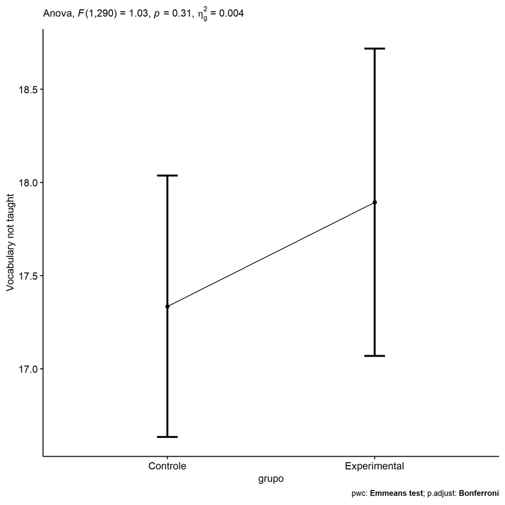

```r
if (!is.null(nrow(plots[["grupo"]]$data)))
  plots[["grupo"]] + ggplot2::ylab("Vocabulary not taught") +
  if (ymin.ci < ymax.ci) ggplot2::ylim(ymin.ci, ymax.ci)
```

```r
plots <- oneWayAncovaBoxPlots(
  wdat, "score.vocab.nao.ensinado.pos", "grupo", aov, pwc, covar = "score.vocab.nao.ensinado.pre",
  theme = "classic", color = color[["grupo"]],
  subtitle = which(aov$Effect == "grupo"))
```

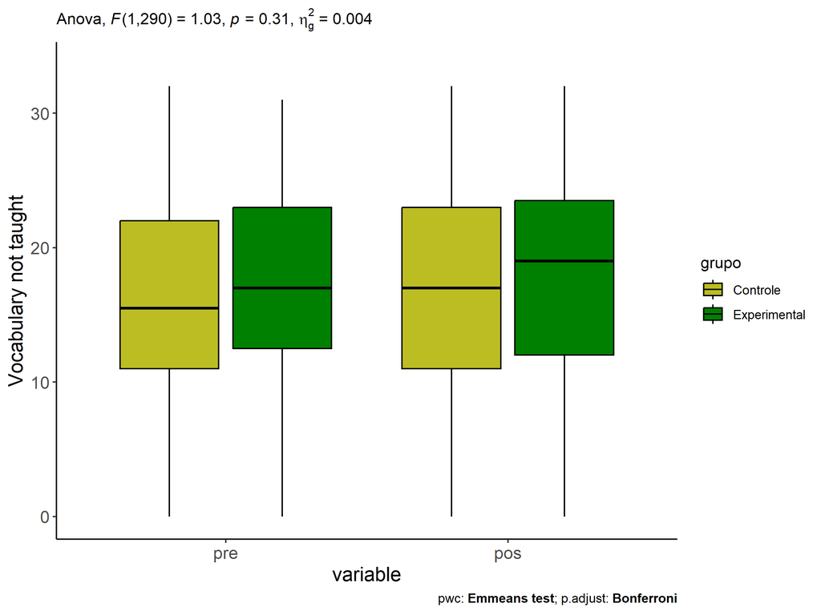

```r
if (length(unique(wdat[["grupo"]])) > 1)
  plots[["grupo"]] + ggplot2::ylab("Vocabulary not taught") +
  ggplot2::scale_x_discrete(labels=c('pre', 'pos')) +
  if (ymin < ymax) ggplot2::ylim(ymin, ymax)
```

```r
if (length(unique(wdat.long[["grupo"]])) > 1)
  plots <- oneWayAncovaBoxPlots(
    wdat.long, "score.vocab.nao.ensinado", "grupo", aov, pwc.long,
    pre.post = "time", theme = "classic", color = color$prepost)
```

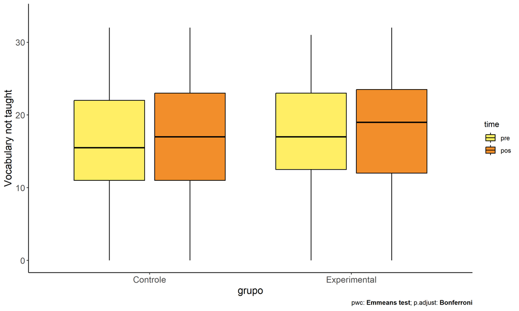

```r
if (length(unique(wdat.long[["grupo"]])) > 1)
  plots[["grupo"]] + ggplot2::ylab("Vocabulary not taught") +
  if (ymin < ymax) ggplot2::ylim(ymin, ymax)
```

### Checking linearity assumption

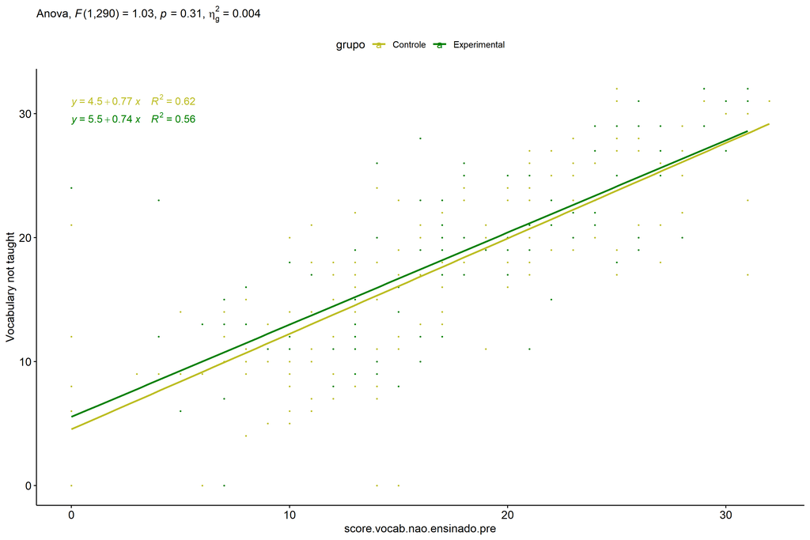

```r
ggscatter(wdat, x = "score.vocab.nao.ensinado.pre", y = "score.vocab.nao.ensinado.pos", size = 0.5,
          color = "grupo", add = "reg.line")+
  stat_regline_equation(
    aes(label =  paste(..eq.label.., ..rr.label.., sep = "~~~~"), color = grupo)
  ) +
  ggplot2::labs(subtitle = rstatix::get_test_label(aov, detailed = T, row = which(aov$Effect == "grupo"))) +
  ggplot2::scale_color_manual(values = color[["grupo"]]) +
  ggplot2::ylab("Vocabulary not taught")  +
  if (ymin < ymax) ggplot2::ylim(ymin, ymax)
```

### Checking normality and homogeneity

```r
res <- augment(lm(score.vocab.nao.ensinado.pos ~ score.vocab.nao.ensinado.pre + grupo, data = wdat))
```

```r
shapiro_test(res$.resid)
```

```
## # A tibble: 1 × 3
##   variable   statistic  p.value
##   <chr>          <dbl>    <dbl>
## 1 res$.resid     0.982 0.000924
```

```r
levene_test(res, .resid ~ grupo)
```

```
## # A tibble: 1 × 4
##     df1   df2 statistic     p
##   <int> <int>     <dbl> <dbl>
## 1     1   291   0.00921 0.924
```

# ANCOVA and Pairwise for two factors **grupo:genero**

## Without remove non-normal data

```r
pdat = remove_group_data(dat[!is.na(dat[["grupo"]]) & !is.na(dat[["genero"]]),],
                         "score.vocab.nao.ensinado.pos", c("grupo","genero"))
pdat = pdat[pdat[["genero"]] %in% do.call(
  intersect, lapply(unique(pdat[["grupo"]]), FUN = function(x) {
    unique(pdat[["genero"]][which(pdat[["grupo"]] == x)])
  })),]
pdat[["grupo"]] = factor(pdat[["grupo"]], level[["grupo"]])
pdat[["genero"]] = factor(
  pdat[["genero"]],
  level[["genero"]][level[["genero"]] %in% unique(pdat[["genero"]])])

pdat.long <- rbind(pdat[,c("id","grupo","genero")], pdat[,c("id","grupo","genero")])
pdat.long[["time"]] <- c(rep("pre", nrow(pdat)), rep("pos", nrow(pdat)))
pdat.long[["time"]] <- factor(pdat.long[["time"]], c("pre","pos"))
pdat.long[["score.vocab.nao.ensinado"]] <- c(pdat[["score.vocab.nao.ensinado.pre"]], pdat[["score.vocab.nao.ensinado.pos"]])

if (length(unique(pdat[["genero"]])) >= 2) {
  aov = anova_test(pdat, score.vocab.nao.ensinado.pos ~ score.vocab.nao.ensinado.pre + grupo*genero)
  laov[["grupo:genero"]] <- get_anova_table(aov)
}
```

```r
if (length(unique(pdat[["genero"]])) >= 2) {
  pwcs <- list()
  pwcs[["genero"]] <- emmeans_test(
    group_by(pdat, grupo), score.vocab.nao.ensinado.pos ~ genero,
    covariate = score.vocab.nao.ensinado.pre, p.adjust.method = "bonferroni")
  pwcs[["grupo"]] <- emmeans_test(
    group_by(pdat, genero), score.vocab.nao.ensinado.pos ~ grupo,
    covariate = score.vocab.nao.ensinado.pre, p.adjust.method = "bonferroni")

  pwc <- plyr::rbind.fill(pwcs[["grupo"]], pwcs[["genero"]])
  pwc <- pwc[,c("grupo","genero", colnames(pwc)[!colnames(pwc) %in% c("grupo","genero")])]
}
```

```r
if (length(unique(pdat[["genero"]])) >= 2) {
  pwc.long <- emmeans_test(dplyr::group_by_at(pdat.long, c("grupo","genero")),
                           score.vocab.nao.ensinado ~ time,
                           p.adjust.method = "bonferroni")
  lpwc[["grupo:genero"]] <- plyr::rbind.fill(pwc, pwc.long)
}
```

```r
if (length(unique(pdat[["genero"]])) >= 2) {
  ds <- get.descriptives(pdat, "score.vocab.nao.ensinado.pos", c("grupo","genero"), covar = "score.vocab.nao.ensinado.pre")
  ds <- merge(ds[ds$variable != "score.vocab.nao.ensinado.pre",],
              ds[ds$variable == "score.vocab.nao.ensinado.pre", !colnames(ds) %in% c("variable")],
              by = c("grupo","genero"), all.x = T, suffixes = c("", ".score.vocab.nao.ensinado.pre"))
  ds <- merge(get_emmeans(pwcs[["grupo"]]), ds,
              by = c("grupo","genero"), suffixes = c(".emms", ""))
  ds <- ds[,c("grupo","genero","n","mean.score.vocab.nao.ensinado.pre","se.score.vocab.nao.ensinado.pre","mean","se",
              "emmean","se.emms","conf.low","conf.high")]

  colnames(ds) <- c("grupo","genero", "N", paste0(c("M","SE")," (pre)"),
                    paste0(c("M","SE"), " (unadj)"),
                    paste0(c("M", "SE"), " (adj)"), "conf.low", "conf.high")

  lemms[["grupo:genero"]] <- ds
}
```

## Computing ANCOVA and PairWise After removing non-normal data (OK)

```r
if (length(unique(pdat[["genero"]])) >= 2) {
  wdat = pdat

  res = residuals(lm(score.vocab.nao.ensinado.pos ~ score.vocab.nao.ensinado.pre + grupo*genero, data = wdat))
  non.normal = getNonNormal(res, wdat$id, plimit = 0.05)

  wdat = wdat[!wdat$id %in% non.normal,]

  wdat.long <- rbind(wdat[,c("id","grupo","genero")], wdat[,c("id","grupo","genero")])
  wdat.long[["time"]] <- c(rep("pre", nrow(wdat)), rep("pos", nrow(wdat)))
  wdat.long[["time"]] <- factor(wdat.long[["time"]], c("pre","pos"))
  wdat.long[["score.vocab.nao.ensinado"]] <- c(wdat[["score.vocab.nao.ensinado.pre"]], wdat[["score.vocab.nao.ensinado.pos"]])


  ldat[["grupo:genero"]] = wdat

  (non.normal)
}
```

```
##  [1] "P187" "P314" "P37"  "P84"  "P46"  "P190" "P79"  "P300" "P294" "P204" "P63"  "P202" "P337"
## [14] "P312" "P179" "P226" "P329" "P323"
```

```r
if (length(unique(pdat[["genero"]])) >= 2) {
  aov = anova_test(wdat, score.vocab.nao.ensinado.pos ~ score.vocab.nao.ensinado.pre + grupo*genero)
  laov[["grupo:genero"]] <- merge(get_anova_table(aov), laov[["grupo:genero"]],
                                         by="Effect", suffixes = c("","'"))
  df = get_anova_table(aov)
}
```

| Effect | DFn | DFd | F | p | p<.05 | ges |
| --- | --- | --- | --- | --- | --- | --- |
| score.vocab.nao.ensinado.pre | 1 | 287 | 452.632 | 0.000 | * | 0.612 |
| grupo | 1 | 287 | 0.144 | 0.705 |  | 0.001 |
| genero | 1 | 287 | 2.099 | 0.148 |  | 0.007 |
| grupo:genero | 1 | 287 | 0.596 | 0.441 |  | 0.002 |

```r
if (length(unique(pdat[["genero"]])) >= 2) {
  pwcs <- list()
  pwcs[["genero"]] <- emmeans_test(
    group_by(wdat, grupo), score.vocab.nao.ensinado.pos ~ genero,
    covariate = score.vocab.nao.ensinado.pre, p.adjust.method = "bonferroni")
  pwcs[["grupo"]] <- emmeans_test(
    group_by(wdat, genero), score.vocab.nao.ensinado.pos ~ grupo,
    covariate = score.vocab.nao.ensinado.pre, p.adjust.method = "bonferroni")

  pwc <- plyr::rbind.fill(pwcs[["grupo"]], pwcs[["genero"]])
  pwc <- pwc[,c("grupo","genero", colnames(pwc)[!colnames(pwc) %in% c("grupo","genero")])]
}
```

| grupo | genero | term | .y. | group1 | group2 | df | statistic | p | p.adj | p.adj.signif |
| --- | --- | --- | --- | --- | --- | --- | --- | --- | --- | --- |
|  | F | score.vocab.nao.ensinado.pre*grupo | score.vocab.nao.ensinado.pos | Controle | Experimental | 287 | 0.305 | 0.760 | 0.760 | ns |
|  | M | score.vocab.nao.ensinado.pre*grupo | score.vocab.nao.ensinado.pos | Controle | Experimental | 287 | -0.803 | 0.423 | 0.423 | ns |
| Controle |  | score.vocab.nao.ensinado.pre*genero | score.vocab.nao.ensinado.pos | F | M | 287 | 1.607 | 0.109 | 0.109 | ns |
| Experimental |  | score.vocab.nao.ensinado.pre*genero | score.vocab.nao.ensinado.pos | F | M | 287 | 0.355 | 0.723 | 0.723 | ns |

```r
if (length(unique(pdat[["genero"]])) >= 2) {
  pwc.long <- emmeans_test(dplyr::group_by_at(wdat.long, c("grupo","genero")),
                           score.vocab.nao.ensinado ~ time,
                           p.adjust.method = "bonferroni")
  lpwc[["grupo:genero"]] <- merge(plyr::rbind.fill(pwc, pwc.long),
                                         lpwc[["grupo:genero"]],
                                         by=c("grupo","genero","term",".y.","group1","group2"),
                                         suffixes = c("","'"))
}
```

| grupo | genero | term | .y. | group1 | group2 | df | statistic | p | p.adj | p.adj.signif |
| --- | --- | --- | --- | --- | --- | --- | --- | --- | --- | --- |
| Controle | F | time | score.vocab.nao.ensinado | pre | pos | 576 | -1.128 | 0.260 | 0.260 | ns |
| Controle | M | time | score.vocab.nao.ensinado | pre | pos | 576 | -0.517 | 0.605 | 0.605 | ns |
| Experimental | F | time | score.vocab.nao.ensinado | pre | pos | 576 | -0.462 | 0.644 | 0.644 | ns |
| Experimental | M | time | score.vocab.nao.ensinado | pre | pos | 576 | -0.772 | 0.441 | 0.441 | ns |

```r
if (length(unique(pdat[["genero"]])) >= 2) {
  ds <- get.descriptives(wdat, "score.vocab.nao.ensinado.pos", c("grupo","genero"), covar = "score.vocab.nao.ensinado.pre")
  ds <- merge(ds[ds$variable != "score.vocab.nao.ensinado.pre",],
              ds[ds$variable == "score.vocab.nao.ensinado.pre", !colnames(ds) %in% c("variable")],
              by = c("grupo","genero"), all.x = T, suffixes = c("", ".score.vocab.nao.ensinado.pre"))
  ds <- merge(get_emmeans(pwcs[["grupo"]]), ds,
              by = c("grupo","genero"), suffixes = c(".emms", ""))
  ds <- ds[,c("grupo","genero","n","mean.score.vocab.nao.ensinado.pre","se.score.vocab.nao.ensinado.pre",
              "mean","se","emmean","se.emms","conf.low","conf.high")]

  colnames(ds) <- c("grupo","genero", "N", paste0(c("M","SE")," (pre)"),
                    paste0(c("M","SE"), " (unadj)"),
                    paste0(c("M", "SE"), " (adj)"), "conf.low", "conf.high")

  lemms[["grupo:genero"]] <- merge(ds, lemms[["grupo:genero"]],
                                          by=c("grupo","genero"), suffixes = c("","'"))
}
```

| grupo | genero | N | M (pre) | SE (pre) | M (unadj) | SE (unadj) | M (adj) | SE (adj) | conf.low | conf.high |
| --- | --- | --- | --- | --- | --- | --- | --- | --- | --- | --- |
| Controle | F | 83 | 17.133 | 0.770 | 18.398 | 0.691 | 18.045 | 0.493 | 17.075 | 19.015 |
| Controle | M | 86 | 15.256 | 0.860 | 15.826 | 0.859 | 16.929 | 0.487 | 15.971 | 17.888 |
| Experimental | F | 55 | 18.873 | 0.980 | 19.509 | 1.114 | 17.806 | 0.611 | 16.604 | 19.008 |
| Experimental | M | 68 | 16.147 | 0.792 | 17.103 | 0.751 | 17.515 | 0.545 | 16.443 | 18.587 |

### Plots for ancova

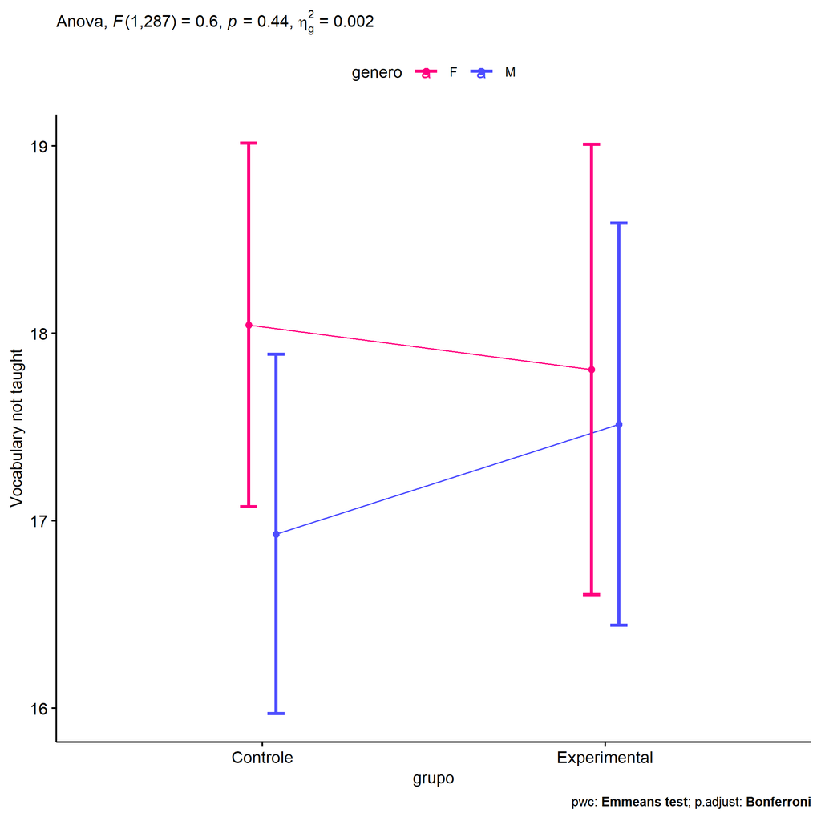

```r
if (length(unique(pdat[["genero"]])) >= 2) {
  ggPlotAoC2(pwcs, "grupo", "genero", aov, ylab = "Vocabulary not taught",
             subtitle = which(aov$Effect == "grupo:genero"), addParam = "errorbar") +
    ggplot2::scale_color_manual(values = color[["genero"]]) +
    ggplot2::ylab("Vocabulary not taught") +
    if (ymin.ci < ymax.ci) ggplot2::ylim(ymin.ci, ymax.ci)
}
```

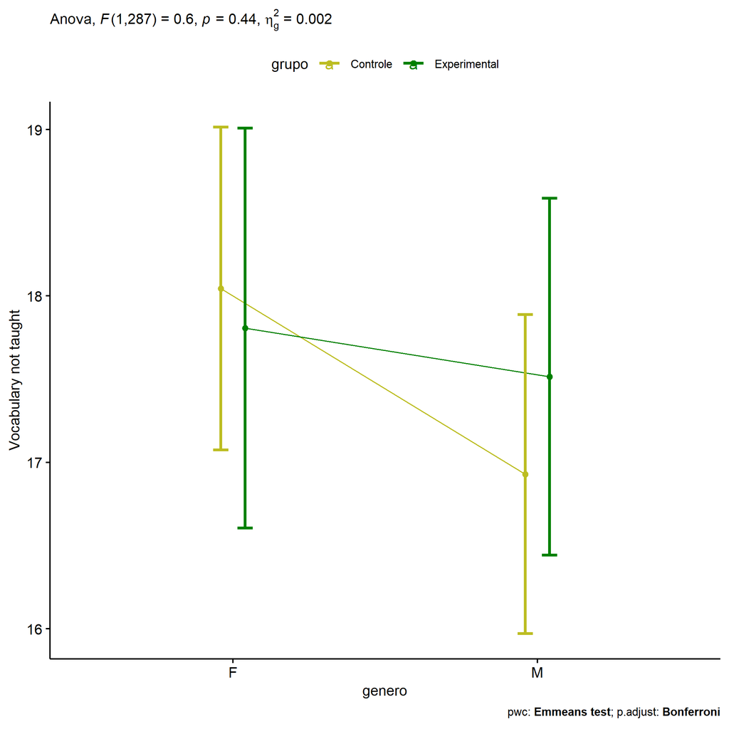

```r
if (length(unique(pdat[["genero"]])) >= 2) {
  ggPlotAoC2(pwcs, "genero", "grupo", aov, ylab = "Vocabulary not taught",
               subtitle = which(aov$Effect == "grupo:genero"), addParam = "errorbar") +
    ggplot2::scale_color_manual(values = color[["grupo"]]) +
    ggplot2::ylab("Vocabulary not taught") +
    if (ymin.ci < ymax.ci) ggplot2::ylim(ymin.ci, ymax.ci)
}
```

```r
if (length(unique(pdat[["genero"]])) >= 2) {
  plots <- twoWayAncovaBoxPlots(
    wdat, "score.vocab.nao.ensinado.pos", c("grupo","genero"), aov, pwcs, covar = "score.vocab.nao.ensinado.pre",
    theme = "classic", color = color[["grupo:genero"]],
    subtitle = which(aov$Effect == "grupo:genero"))
}
```

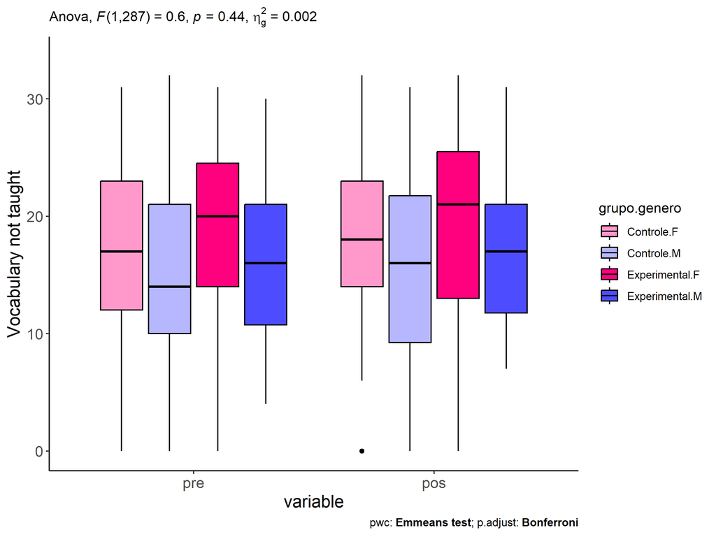

```r
if (length(unique(pdat[["genero"]])) >= 2) {
  plots[["grupo:genero"]] + ggplot2::ylab("Vocabulary not taught") +
  ggplot2::scale_x_discrete(labels=c('pre', 'pos')) +
  if (ymin < ymax) ggplot2::ylim(ymin, ymax)
}
```

```r
if (length(unique(pdat[["genero"]])) >= 2) {
  plots <- twoWayAncovaBoxPlots(
    wdat.long, "score.vocab.nao.ensinado", c("grupo","genero"), aov, pwc.long,
    pre.post = "time",
    theme = "classic", color = color$prepost)
}
```

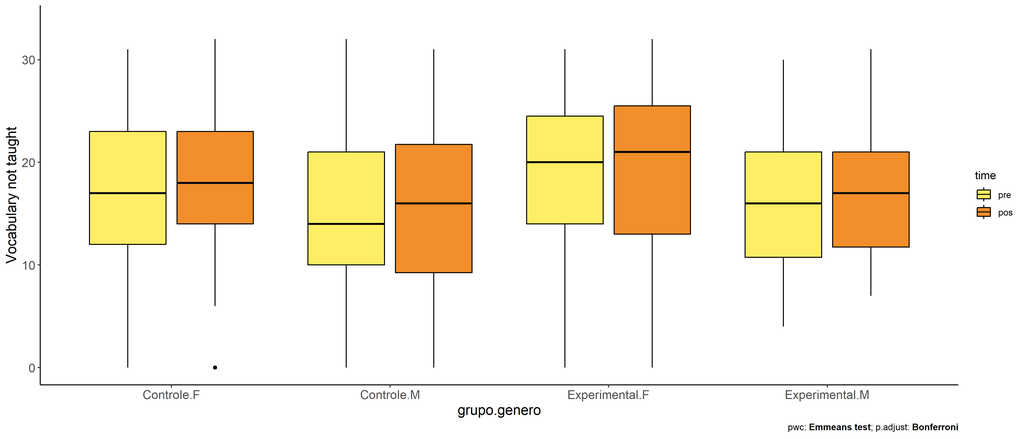

```r
if (length(unique(pdat[["genero"]])) >= 2)
  plots[["grupo:genero"]] + ggplot2::ylab("Vocabulary not taught") +
    if (ymin < ymax) ggplot2::ylim(ymin, ymax)
```

### Checking linearity assumption

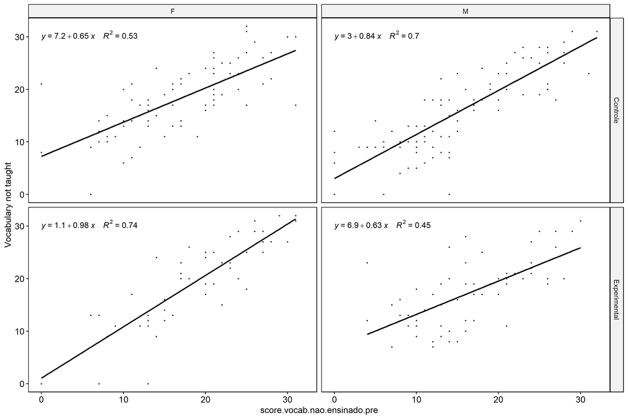

```r
if (length(unique(pdat[["genero"]])) >= 2) {
  ggscatter(wdat, x = "score.vocab.nao.ensinado.pre", y = "score.vocab.nao.ensinado.pos", size = 0.5,
            facet.by = c("grupo","genero"), add = "reg.line")+
    stat_regline_equation(
      aes(label =  paste(..eq.label.., ..rr.label.., sep = "~~~~"))
    ) + ggplot2::ylab("Vocabulary not taught") +
    if (ymin < ymax) ggplot2::ylim(ymin, ymax)
}
```

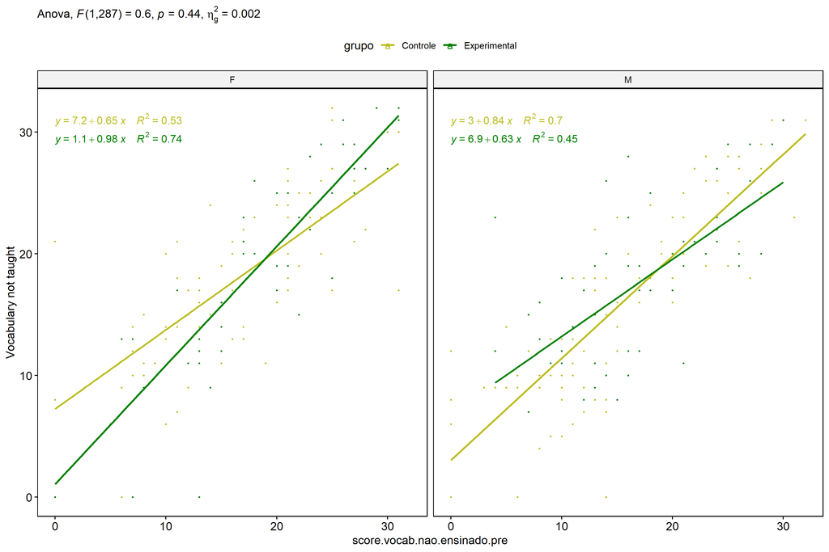

```r
if (length(unique(pdat[["genero"]])) >= 2) {
  ggscatter(wdat, x = "score.vocab.nao.ensinado.pre", y = "score.vocab.nao.ensinado.pos", size = 0.5,
            color = "grupo", facet.by = "genero", add = "reg.line")+
    stat_regline_equation(
      aes(label =  paste(..eq.label.., ..rr.label.., sep = "~~~~"), color = grupo)
    ) +
    ggplot2::labs(subtitle = rstatix::get_test_label(aov, detailed = T, row = which(aov$Effect == "grupo:genero"))) +
    ggplot2::scale_color_manual(values = color[["grupo"]]) +
    ggplot2::ylab("Vocabulary not taught") +
    if (ymin < ymax) ggplot2::ylim(ymin, ymax)
}
```

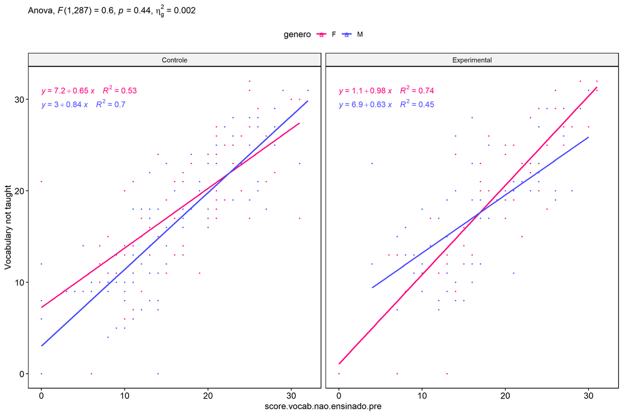

```r
if (length(unique(pdat[["genero"]])) >= 2) {
  ggscatter(wdat, x = "score.vocab.nao.ensinado.pre", y = "score.vocab.nao.ensinado.pos", size = 0.5,
            color = "genero", facet.by = "grupo", add = "reg.line")+
    stat_regline_equation(
      aes(label =  paste(..eq.label.., ..rr.label.., sep = "~~~~"), color = genero)
    ) +
    ggplot2::labs(subtitle = rstatix::get_test_label(aov, detailed = T, row = which(aov$Effect == "grupo:genero"))) +
    ggplot2::scale_color_manual(values = color[["genero"]]) +
    ggplot2::ylab("Vocabulary not taught") +
    if (ymin < ymax) ggplot2::ylim(ymin, ymax)
}
```

### Checking normality and homogeneity

```r
if (length(unique(pdat[["genero"]])) >= 2)
  res <- augment(lm(score.vocab.nao.ensinado.pos ~ score.vocab.nao.ensinado.pre + grupo*genero, data = wdat))
```

```r
if (length(unique(pdat[["genero"]])) >= 2)
  shapiro_test(res$.resid)
```

```
## # A tibble: 1 × 3
##   variable   statistic p.value
##   <chr>          <dbl>   <dbl>
## 1 res$.resid     0.988  0.0185
```

```r
if (length(unique(pdat[["genero"]])) >= 2)
  levene_test(res, .resid ~ grupo*genero)
```

```
## # A tibble: 1 × 4
##     df1   df2 statistic     p
##   <int> <int>     <dbl> <dbl>
## 1     3   288    0.0793 0.971
```

# ANCOVA and Pairwise for two factors **grupo:zona.participante**

## Without remove non-normal data

```r
pdat = remove_group_data(dat[!is.na(dat[["grupo"]]) & !is.na(dat[["zona.participante"]]),],
                         "score.vocab.nao.ensinado.pos", c("grupo","zona.participante"))
pdat = pdat[pdat[["zona.participante"]] %in% do.call(
  intersect, lapply(unique(pdat[["grupo"]]), FUN = function(x) {
    unique(pdat[["zona.participante"]][which(pdat[["grupo"]] == x)])
  })),]
pdat[["grupo"]] = factor(pdat[["grupo"]], level[["grupo"]])
pdat[["zona.participante"]] = factor(
  pdat[["zona.participante"]],
  level[["zona.participante"]][level[["zona.participante"]] %in% unique(pdat[["zona.participante"]])])

pdat.long <- rbind(pdat[,c("id","grupo","zona.participante")], pdat[,c("id","grupo","zona.participante")])
pdat.long[["time"]] <- c(rep("pre", nrow(pdat)), rep("pos", nrow(pdat)))
pdat.long[["time"]] <- factor(pdat.long[["time"]], c("pre","pos"))
pdat.long[["score.vocab.nao.ensinado"]] <- c(pdat[["score.vocab.nao.ensinado.pre"]], pdat[["score.vocab.nao.ensinado.pos"]])

if (length(unique(pdat[["zona.participante"]])) >= 2) {
  aov = anova_test(pdat, score.vocab.nao.ensinado.pos ~ score.vocab.nao.ensinado.pre + grupo*zona.participante)
  laov[["grupo:zona.participante"]] <- get_anova_table(aov)
}
```

```r
if (length(unique(pdat[["zona.participante"]])) >= 2) {
  pwcs <- list()
  pwcs[["zona.participante"]] <- emmeans_test(
    group_by(pdat, grupo), score.vocab.nao.ensinado.pos ~ zona.participante,
    covariate = score.vocab.nao.ensinado.pre, p.adjust.method = "bonferroni")
  pwcs[["grupo"]] <- emmeans_test(
    group_by(pdat, zona.participante), score.vocab.nao.ensinado.pos ~ grupo,
    covariate = score.vocab.nao.ensinado.pre, p.adjust.method = "bonferroni")

  pwc <- plyr::rbind.fill(pwcs[["grupo"]], pwcs[["zona.participante"]])
  pwc <- pwc[,c("grupo","zona.participante", colnames(pwc)[!colnames(pwc) %in% c("grupo","zona.participante")])]
}
```

```r
if (length(unique(pdat[["zona.participante"]])) >= 2) {
  pwc.long <- emmeans_test(dplyr::group_by_at(pdat.long, c("grupo","zona.participante")),
                           score.vocab.nao.ensinado ~ time,
                           p.adjust.method = "bonferroni")
  lpwc[["grupo:zona.participante"]] <- plyr::rbind.fill(pwc, pwc.long)
}
```

```r
if (length(unique(pdat[["zona.participante"]])) >= 2) {
  ds <- get.descriptives(pdat, "score.vocab.nao.ensinado.pos", c("grupo","zona.participante"), covar = "score.vocab.nao.ensinado.pre")
  ds <- merge(ds[ds$variable != "score.vocab.nao.ensinado.pre",],
              ds[ds$variable == "score.vocab.nao.ensinado.pre", !colnames(ds) %in% c("variable")],
              by = c("grupo","zona.participante"), all.x = T, suffixes = c("", ".score.vocab.nao.ensinado.pre"))
  ds <- merge(get_emmeans(pwcs[["grupo"]]), ds,
              by = c("grupo","zona.participante"), suffixes = c(".emms", ""))
  ds <- ds[,c("grupo","zona.participante","n","mean.score.vocab.nao.ensinado.pre","se.score.vocab.nao.ensinado.pre","mean","se",
              "emmean","se.emms","conf.low","conf.high")]

  colnames(ds) <- c("grupo","zona.participante", "N", paste0(c("M","SE")," (pre)"),
                    paste0(c("M","SE"), " (unadj)"),
                    paste0(c("M", "SE"), " (adj)"), "conf.low", "conf.high")

  lemms[["grupo:zona.participante"]] <- ds
}
```

## Computing ANCOVA and PairWise After removing non-normal data (OK)

```r
if (length(unique(pdat[["zona.participante"]])) >= 2) {
  wdat = pdat

  res = residuals(lm(score.vocab.nao.ensinado.pos ~ score.vocab.nao.ensinado.pre + grupo*zona.participante, data = wdat))
  non.normal = getNonNormal(res, wdat$id, plimit = 0.05)

  wdat = wdat[!wdat$id %in% non.normal,]

  wdat.long <- rbind(wdat[,c("id","grupo","zona.participante")], wdat[,c("id","grupo","zona.participante")])
  wdat.long[["time"]] <- c(rep("pre", nrow(wdat)), rep("pos", nrow(wdat)))
  wdat.long[["time"]] <- factor(wdat.long[["time"]], c("pre","pos"))
  wdat.long[["score.vocab.nao.ensinado"]] <- c(wdat[["score.vocab.nao.ensinado.pre"]], wdat[["score.vocab.nao.ensinado.pos"]])


  ldat[["grupo:zona.participante"]] = wdat

  (non.normal)
}
```

```
## [1] "P187" "P37"  "P84"  "P46"  "P226" "P294" "P323" "P337"
```

```r
if (length(unique(pdat[["zona.participante"]])) >= 2) {
  aov = anova_test(wdat, score.vocab.nao.ensinado.pos ~ score.vocab.nao.ensinado.pre + grupo*zona.participante)
  laov[["grupo:zona.participante"]] <- merge(get_anova_table(aov), laov[["grupo:zona.participante"]],
                                         by="Effect", suffixes = c("","'"))
  df = get_anova_table(aov)
}
```

| Effect | DFn | DFd | F | p | p<.05 | ges |
| --- | --- | --- | --- | --- | --- | --- |
| score.vocab.nao.ensinado.pre | 1 | 221 | 295.905 | 0.000 | * | 0.572 |
| grupo | 1 | 221 | 0.348 | 0.556 |  | 0.002 |
| zona.participante | 1 | 221 | 4.537 | 0.034 | * | 0.020 |
| grupo:zona.participante | 1 | 221 | 2.640 | 0.106 |  | 0.012 |

```r
if (length(unique(pdat[["zona.participante"]])) >= 2) {
  pwcs <- list()
  pwcs[["zona.participante"]] <- emmeans_test(
    group_by(wdat, grupo), score.vocab.nao.ensinado.pos ~ zona.participante,
    covariate = score.vocab.nao.ensinado.pre, p.adjust.method = "bonferroni")
  pwcs[["grupo"]] <- emmeans_test(
    group_by(wdat, zona.participante), score.vocab.nao.ensinado.pos ~ grupo,
    covariate = score.vocab.nao.ensinado.pre, p.adjust.method = "bonferroni")

  pwc <- plyr::rbind.fill(pwcs[["grupo"]], pwcs[["zona.participante"]])
  pwc <- pwc[,c("grupo","zona.participante", colnames(pwc)[!colnames(pwc) %in% c("grupo","zona.participante")])]
}
```

| grupo | zona.participante | term | .y. | group1 | group2 | df | statistic | p | p.adj | p.adj.signif |
| --- | --- | --- | --- | --- | --- | --- | --- | --- | --- | --- |
|  | Rural | score.vocab.nao.ensinado.pre*grupo | score.vocab.nao.ensinado.pos | Controle | Experimental | 221 | -1.579 | 0.116 | 0.116 | ns |
|  | Urbana | score.vocab.nao.ensinado.pre*grupo | score.vocab.nao.ensinado.pos | Controle | Experimental | 221 | 0.698 | 0.486 | 0.486 | ns |
| Controle |  | score.vocab.nao.ensinado.pre*zona.participante | score.vocab.nao.ensinado.pos | Rural | Urbana | 221 | 0.546 | 0.586 | 0.586 | ns |
| Experimental |  | score.vocab.nao.ensinado.pre*zona.participante | score.vocab.nao.ensinado.pos | Rural | Urbana | 221 | 2.627 | 0.009 | 0.009 | ** |

```r
if (length(unique(pdat[["zona.participante"]])) >= 2) {
  pwc.long <- emmeans_test(dplyr::group_by_at(wdat.long, c("grupo","zona.participante")),
                           score.vocab.nao.ensinado ~ time,
                           p.adjust.method = "bonferroni")
  lpwc[["grupo:zona.participante"]] <- merge(plyr::rbind.fill(pwc, pwc.long),
                                         lpwc[["grupo:zona.participante"]],
                                         by=c("grupo","zona.participante","term",".y.","group1","group2"),
                                         suffixes = c("","'"))
}
```

| grupo | zona.participante | term | .y. | group1 | group2 | df | statistic | p | p.adj | p.adj.signif |
| --- | --- | --- | --- | --- | --- | --- | --- | --- | --- | --- |
| Controle | Rural | time | score.vocab.nao.ensinado | pre | pos | 444 | -1.195 | 0.233 | 0.233 | ns |
| Controle | Urbana | time | score.vocab.nao.ensinado | pre | pos | 444 | -0.598 | 0.550 | 0.550 | ns |
| Experimental | Rural | time | score.vocab.nao.ensinado | pre | pos | 444 | -1.932 | 0.054 | 0.054 | ns |
| Experimental | Urbana | time | score.vocab.nao.ensinado | pre | pos | 444 | 0.158 | 0.875 | 0.875 | ns |

```r
if (length(unique(pdat[["zona.participante"]])) >= 2) {
  ds <- get.descriptives(wdat, "score.vocab.nao.ensinado.pos", c("grupo","zona.participante"), covar = "score.vocab.nao.ensinado.pre")
  ds <- merge(ds[ds$variable != "score.vocab.nao.ensinado.pre",],
              ds[ds$variable == "score.vocab.nao.ensinado.pre", !colnames(ds) %in% c("variable")],
              by = c("grupo","zona.participante"), all.x = T, suffixes = c("", ".score.vocab.nao.ensinado.pre"))
  ds <- merge(get_emmeans(pwcs[["grupo"]]), ds,
              by = c("grupo","zona.participante"), suffixes = c(".emms", ""))
  ds <- ds[,c("grupo","zona.participante","n","mean.score.vocab.nao.ensinado.pre","se.score.vocab.nao.ensinado.pre",
              "mean","se","emmean","se.emms","conf.low","conf.high")]

  colnames(ds) <- c("grupo","zona.participante", "N", paste0(c("M","SE")," (pre)"),
                    paste0(c("M","SE"), " (unadj)"),
                    paste0(c("M", "SE"), " (adj)"), "conf.low", "conf.high")

  lemms[["grupo:zona.participante"]] <- merge(ds, lemms[["grupo:zona.participante"]],
                                          by=c("grupo","zona.participante"), suffixes = c("","'"))
}
```

| grupo | zona.participante | N | M (pre) | SE (pre) | M (unadj) | SE (unadj) | M (adj) | SE (adj) | conf.low | conf.high |
| --- | --- | --- | --- | --- | --- | --- | --- | --- | --- | --- |
| Controle | Rural | 56 | 15.304 | 1.017 | 16.929 | 0.850 | 17.998 | 0.626 | 16.763 | 19.232 |
| Controle | Urbana | 73 | 17.068 | 0.857 | 17.781 | 0.862 | 17.543 | 0.546 | 16.467 | 18.619 |
| Experimental | Rural | 50 | 16.380 | 0.974 | 19.160 | 0.927 | 19.432 | 0.660 | 18.132 | 20.732 |
| Experimental | Urbana | 47 | 18.362 | 1.049 | 18.128 | 1.179 | 16.933 | 0.684 | 15.585 | 18.281 |

### Plots for ancova

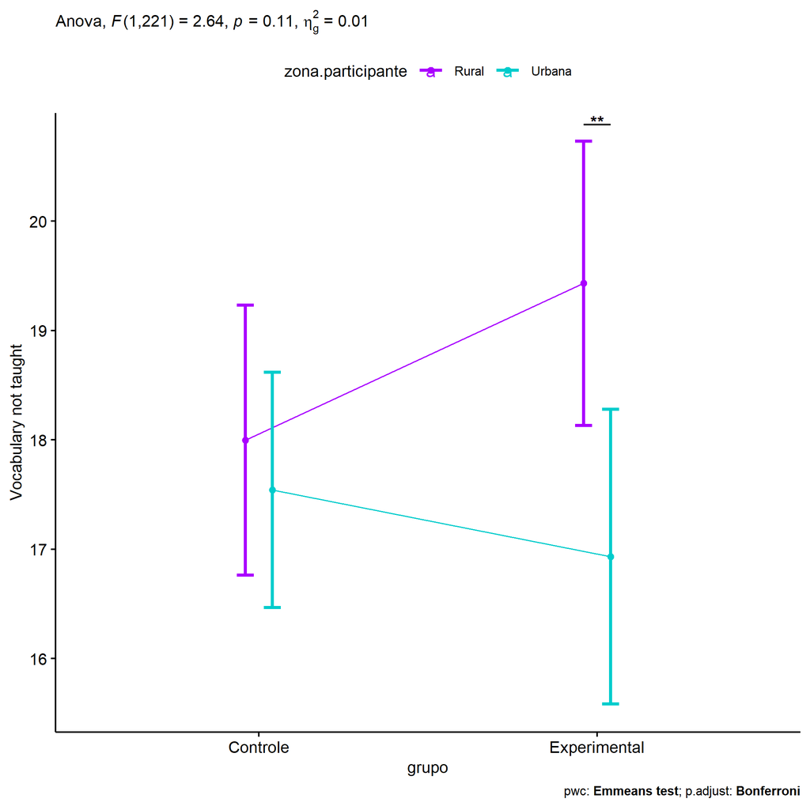

```r
if (length(unique(pdat[["zona.participante"]])) >= 2) {
  ggPlotAoC2(pwcs, "grupo", "zona.participante", aov, ylab = "Vocabulary not taught",
             subtitle = which(aov$Effect == "grupo:zona.participante"), addParam = "errorbar") +
    ggplot2::scale_color_manual(values = color[["zona.participante"]]) +
    ggplot2::ylab("Vocabulary not taught") +
    if (ymin.ci < ymax.ci) ggplot2::ylim(ymin.ci, ymax.ci)
}
```

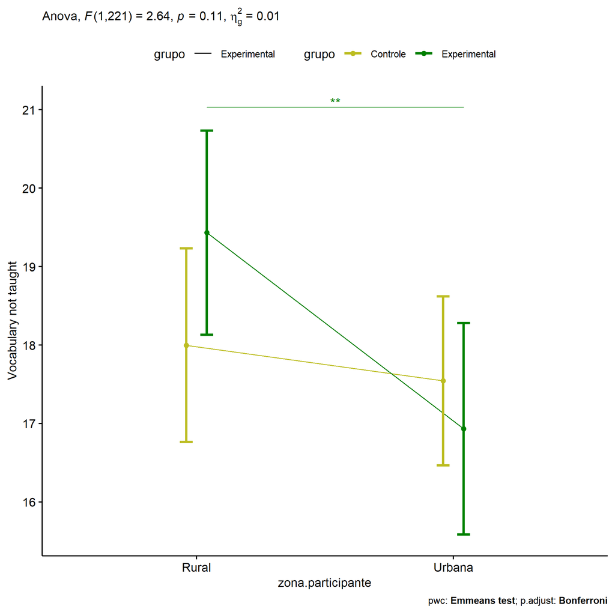

```r
if (length(unique(pdat[["zona.participante"]])) >= 2) {
  ggPlotAoC2(pwcs, "zona.participante", "grupo", aov, ylab = "Vocabulary not taught",
               subtitle = which(aov$Effect == "grupo:zona.participante"), addParam = "errorbar") +
    ggplot2::scale_color_manual(values = color[["grupo"]]) +
    ggplot2::ylab("Vocabulary not taught") +
    if (ymin.ci < ymax.ci) ggplot2::ylim(ymin.ci, ymax.ci)
}
```

```r
if (length(unique(pdat[["zona.participante"]])) >= 2) {
  plots <- twoWayAncovaBoxPlots(
    wdat, "score.vocab.nao.ensinado.pos", c("grupo","zona.participante"), aov, pwcs, covar = "score.vocab.nao.ensinado.pre",
    theme = "classic", color = color[["grupo:zona.participante"]],
    subtitle = which(aov$Effect == "grupo:zona.participante"))
}
```

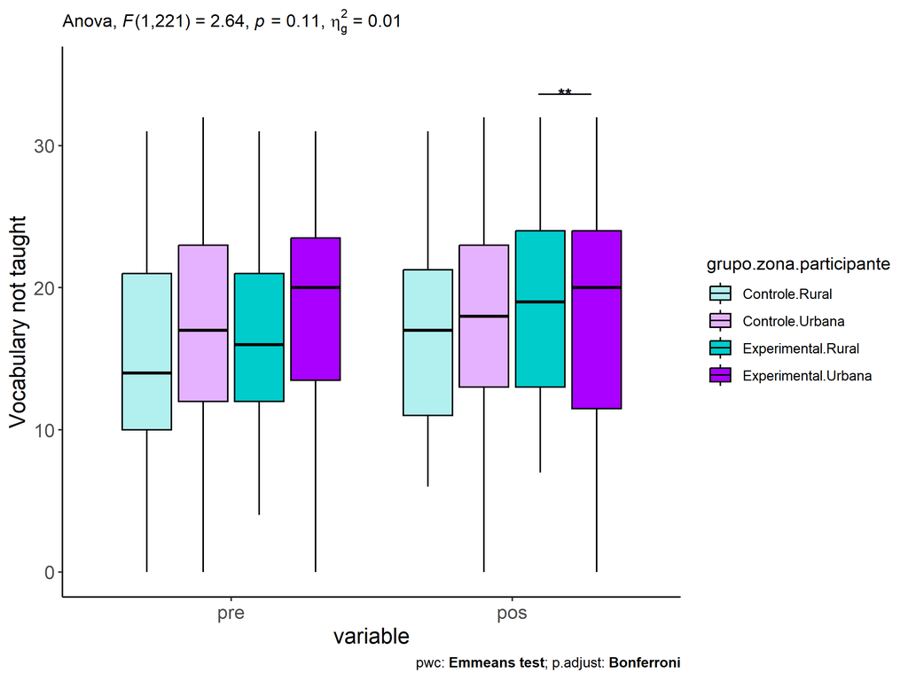

```r
if (length(unique(pdat[["zona.participante"]])) >= 2) {
  plots[["grupo:zona.participante"]] + ggplot2::ylab("Vocabulary not taught") +
  ggplot2::scale_x_discrete(labels=c('pre', 'pos')) +
  if (ymin < ymax) ggplot2::ylim(ymin, ymax)
}
```

```r
if (length(unique(pdat[["zona.participante"]])) >= 2) {
  plots <- twoWayAncovaBoxPlots(
    wdat.long, "score.vocab.nao.ensinado", c("grupo","zona.participante"), aov, pwc.long,
    pre.post = "time",
    theme = "classic", color = color$prepost)
}
```

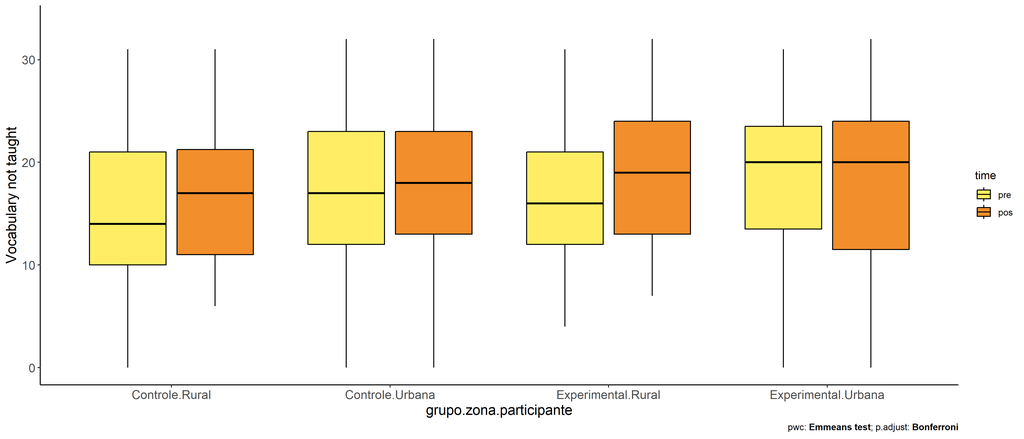

```r
if (length(unique(pdat[["zona.participante"]])) >= 2)
  plots[["grupo:zona.participante"]] + ggplot2::ylab("Vocabulary not taught") +
    if (ymin < ymax) ggplot2::ylim(ymin, ymax)
```

### Checking linearity assumption

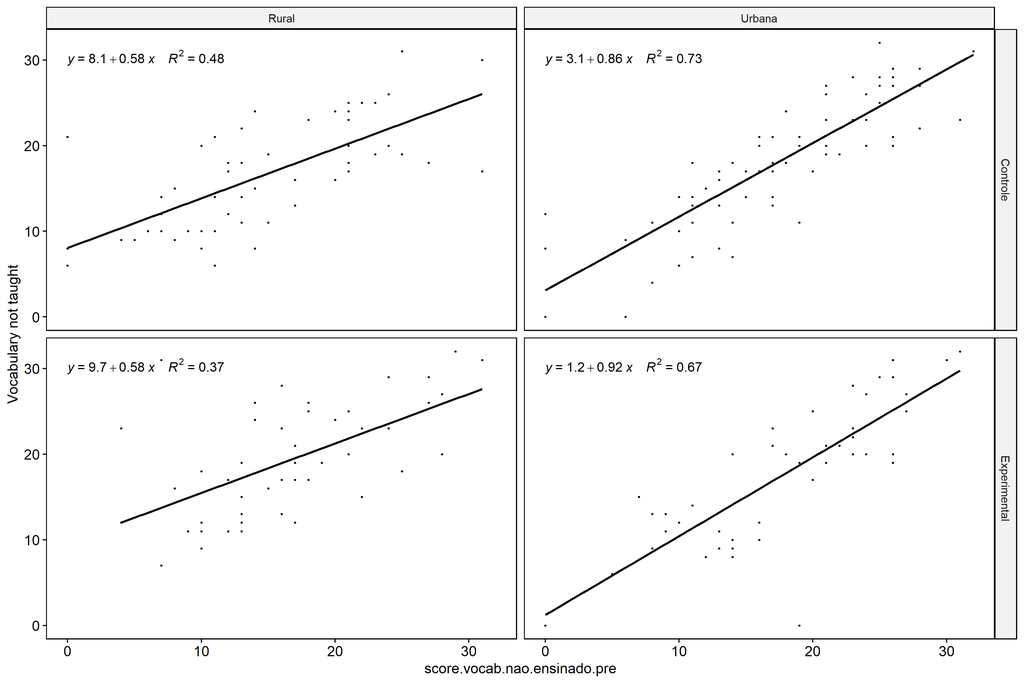

```r
if (length(unique(pdat[["zona.participante"]])) >= 2) {
  ggscatter(wdat, x = "score.vocab.nao.ensinado.pre", y = "score.vocab.nao.ensinado.pos", size = 0.5,
            facet.by = c("grupo","zona.participante"), add = "reg.line")+
    stat_regline_equation(
      aes(label =  paste(..eq.label.., ..rr.label.., sep = "~~~~"))
    ) + ggplot2::ylab("Vocabulary not taught") +
    if (ymin < ymax) ggplot2::ylim(ymin, ymax)
}
```

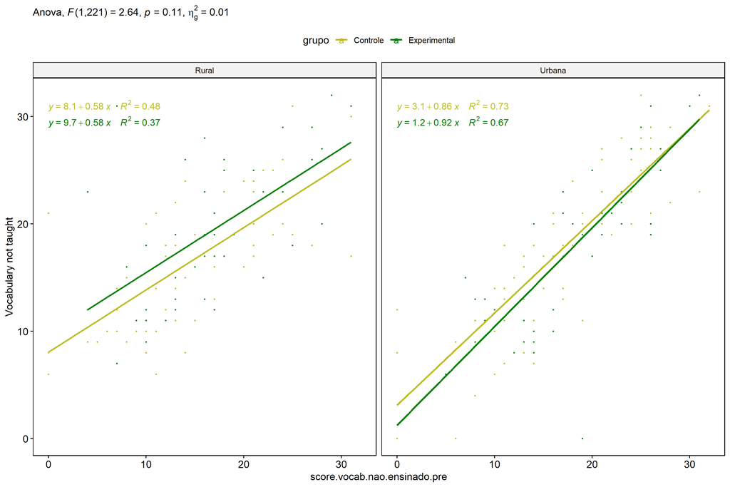

```r
if (length(unique(pdat[["zona.participante"]])) >= 2) {
  ggscatter(wdat, x = "score.vocab.nao.ensinado.pre", y = "score.vocab.nao.ensinado.pos", size = 0.5,
            color = "grupo", facet.by = "zona.participante", add = "reg.line")+
    stat_regline_equation(
      aes(label =  paste(..eq.label.., ..rr.label.., sep = "~~~~"), color = grupo)
    ) +
    ggplot2::labs(subtitle = rstatix::get_test_label(aov, detailed = T, row = which(aov$Effect == "grupo:zona.participante"))) +
    ggplot2::scale_color_manual(values = color[["grupo"]]) +
    ggplot2::ylab("Vocabulary not taught") +
    if (ymin < ymax) ggplot2::ylim(ymin, ymax)
}
```

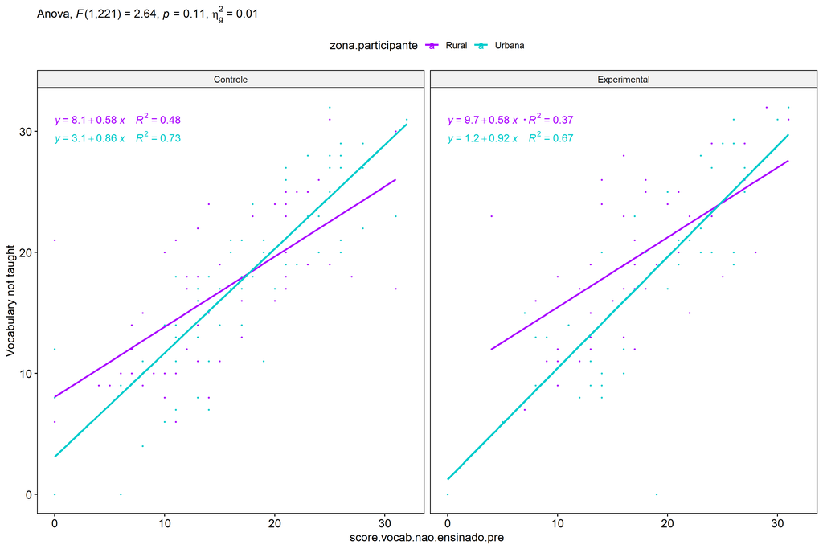

```r
if (length(unique(pdat[["zona.participante"]])) >= 2) {
  ggscatter(wdat, x = "score.vocab.nao.ensinado.pre", y = "score.vocab.nao.ensinado.pos", size = 0.5,
            color = "zona.participante", facet.by = "grupo", add = "reg.line")+
    stat_regline_equation(
      aes(label =  paste(..eq.label.., ..rr.label.., sep = "~~~~"), color = zona.participante)
    ) +
    ggplot2::labs(subtitle = rstatix::get_test_label(aov, detailed = T, row = which(aov$Effect == "grupo:zona.participante"))) +
    ggplot2::scale_color_manual(values = color[["zona.participante"]]) +
    ggplot2::ylab("Vocabulary not taught") +
    if (ymin < ymax) ggplot2::ylim(ymin, ymax)
}
```

### Checking normality and homogeneity

```r
if (length(unique(pdat[["zona.participante"]])) >= 2)
  res <- augment(lm(score.vocab.nao.ensinado.pos ~ score.vocab.nao.ensinado.pre + grupo*zona.participante, data = wdat))
```

```r
if (length(unique(pdat[["zona.participante"]])) >= 2)
  shapiro_test(res$.resid)
```

```
## # A tibble: 1 × 3
##   variable   statistic p.value
##   <chr>          <dbl>   <dbl>
## 1 res$.resid     0.980 0.00320
```

```r
if (length(unique(pdat[["zona.participante"]])) >= 2)
  levene_test(res, .resid ~ grupo*zona.participante)
```

```
## # A tibble: 1 × 4
##     df1   df2 statistic     p
##   <int> <int>     <dbl> <dbl>
## 1     3   222      1.01 0.388
```

# ANCOVA and Pairwise for two factors **grupo:zona.escola**

## Without remove non-normal data

```r
pdat = remove_group_data(dat[!is.na(dat[["grupo"]]) & !is.na(dat[["zona.escola"]]),],
                         "score.vocab.nao.ensinado.pos", c("grupo","zona.escola"))
pdat = pdat[pdat[["zona.escola"]] %in% do.call(
  intersect, lapply(unique(pdat[["grupo"]]), FUN = function(x) {
    unique(pdat[["zona.escola"]][which(pdat[["grupo"]] == x)])
  })),]
pdat[["grupo"]] = factor(pdat[["grupo"]], level[["grupo"]])
pdat[["zona.escola"]] = factor(
  pdat[["zona.escola"]],
  level[["zona.escola"]][level[["zona.escola"]] %in% unique(pdat[["zona.escola"]])])

pdat.long <- rbind(pdat[,c("id","grupo","zona.escola")], pdat[,c("id","grupo","zona.escola")])
pdat.long[["time"]] <- c(rep("pre", nrow(pdat)), rep("pos", nrow(pdat)))
pdat.long[["time"]] <- factor(pdat.long[["time"]], c("pre","pos"))
pdat.long[["score.vocab.nao.ensinado"]] <- c(pdat[["score.vocab.nao.ensinado.pre"]], pdat[["score.vocab.nao.ensinado.pos"]])

if (length(unique(pdat[["zona.escola"]])) >= 2) {
  aov = anova_test(pdat, score.vocab.nao.ensinado.pos ~ score.vocab.nao.ensinado.pre + grupo*zona.escola)
  laov[["grupo:zona.escola"]] <- get_anova_table(aov)
}
```

```r
if (length(unique(pdat[["zona.escola"]])) >= 2) {
  pwcs <- list()
  pwcs[["zona.escola"]] <- emmeans_test(
    group_by(pdat, grupo), score.vocab.nao.ensinado.pos ~ zona.escola,
    covariate = score.vocab.nao.ensinado.pre, p.adjust.method = "bonferroni")
  pwcs[["grupo"]] <- emmeans_test(
    group_by(pdat, zona.escola), score.vocab.nao.ensinado.pos ~ grupo,
    covariate = score.vocab.nao.ensinado.pre, p.adjust.method = "bonferroni")

  pwc <- plyr::rbind.fill(pwcs[["grupo"]], pwcs[["zona.escola"]])
  pwc <- pwc[,c("grupo","zona.escola", colnames(pwc)[!colnames(pwc) %in% c("grupo","zona.escola")])]
}
```

```r
if (length(unique(pdat[["zona.escola"]])) >= 2) {
  pwc.long <- emmeans_test(dplyr::group_by_at(pdat.long, c("grupo","zona.escola")),
                           score.vocab.nao.ensinado ~ time,
                           p.adjust.method = "bonferroni")
  lpwc[["grupo:zona.escola"]] <- plyr::rbind.fill(pwc, pwc.long)
}
```

```r
if (length(unique(pdat[["zona.escola"]])) >= 2) {
  ds <- get.descriptives(pdat, "score.vocab.nao.ensinado.pos", c("grupo","zona.escola"), covar = "score.vocab.nao.ensinado.pre")
  ds <- merge(ds[ds$variable != "score.vocab.nao.ensinado.pre",],
              ds[ds$variable == "score.vocab.nao.ensinado.pre", !colnames(ds) %in% c("variable")],
              by = c("grupo","zona.escola"), all.x = T, suffixes = c("", ".score.vocab.nao.ensinado.pre"))
  ds <- merge(get_emmeans(pwcs[["grupo"]]), ds,
              by = c("grupo","zona.escola"), suffixes = c(".emms", ""))
  ds <- ds[,c("grupo","zona.escola","n","mean.score.vocab.nao.ensinado.pre","se.score.vocab.nao.ensinado.pre","mean","se",
              "emmean","se.emms","conf.low","conf.high")]

  colnames(ds) <- c("grupo","zona.escola", "N", paste0(c("M","SE")," (pre)"),
                    paste0(c("M","SE"), " (unadj)"),
                    paste0(c("M", "SE"), " (adj)"), "conf.low", "conf.high")

  lemms[["grupo:zona.escola"]] <- ds
}
```

## Computing ANCOVA and PairWise After removing non-normal data (OK)

```r
if (length(unique(pdat[["zona.escola"]])) >= 2) {
  wdat = pdat

  res = residuals(lm(score.vocab.nao.ensinado.pos ~ score.vocab.nao.ensinado.pre + grupo*zona.escola, data = wdat))
  non.normal = getNonNormal(res, wdat$id, plimit = 0.05)

  wdat = wdat[!wdat$id %in% non.normal,]

  wdat.long <- rbind(wdat[,c("id","grupo","zona.escola")], wdat[,c("id","grupo","zona.escola")])
  wdat.long[["time"]] <- c(rep("pre", nrow(wdat)), rep("pos", nrow(wdat)))
  wdat.long[["time"]] <- factor(wdat.long[["time"]], c("pre","pos"))
  wdat.long[["score.vocab.nao.ensinado"]] <- c(wdat[["score.vocab.nao.ensinado.pre"]], wdat[["score.vocab.nao.ensinado.pos"]])


  ldat[["grupo:zona.escola"]] = wdat

  (non.normal)
}
```

```
##  [1] "P314" "P187" "P20"  "P84"  "P37"  "P179" "P190" "P79"  "P46"  "P202" "P323" "P204" "P226"
## [14] "P300" "P312" "P103" "P337" "P17"
```

```r
if (length(unique(pdat[["zona.escola"]])) >= 2) {
  aov = anova_test(wdat, score.vocab.nao.ensinado.pos ~ score.vocab.nao.ensinado.pre + grupo*zona.escola)
  laov[["grupo:zona.escola"]] <- merge(get_anova_table(aov), laov[["grupo:zona.escola"]],
                                         by="Effect", suffixes = c("","'"))
  df = get_anova_table(aov)
}
```

| Effect | DFn | DFd | F | p | p<.05 | ges |
| --- | --- | --- | --- | --- | --- | --- |
| score.vocab.nao.ensinado.pre | 1 | 288 | 423.801 | 0.000 | * | 0.595 |
| grupo | 1 | 288 | 0.348 | 0.555 |  | 0.001 |
| zona.escola | 1 | 288 | 1.066 | 0.303 |  | 0.004 |
| grupo:zona.escola | 1 | 288 | 0.188 | 0.665 |  | 0.001 |

```r
if (length(unique(pdat[["zona.escola"]])) >= 2) {
  pwcs <- list()
  pwcs[["zona.escola"]] <- emmeans_test(
    group_by(wdat, grupo), score.vocab.nao.ensinado.pos ~ zona.escola,
    covariate = score.vocab.nao.ensinado.pre, p.adjust.method = "bonferroni")
  pwcs[["grupo"]] <- emmeans_test(
    group_by(wdat, zona.escola), score.vocab.nao.ensinado.pos ~ grupo,
    covariate = score.vocab.nao.ensinado.pre, p.adjust.method = "bonferroni")

  pwc <- plyr::rbind.fill(pwcs[["grupo"]], pwcs[["zona.escola"]])
  pwc <- pwc[,c("grupo","zona.escola", colnames(pwc)[!colnames(pwc) %in% c("grupo","zona.escola")])]
}
```

| grupo | zona.escola | term | .y. | group1 | group2 | df | statistic | p | p.adj | p.adj.signif |
| --- | --- | --- | --- | --- | --- | --- | --- | --- | --- | --- |
|  | Rural | score.vocab.nao.ensinado.pre*grupo | score.vocab.nao.ensinado.pos | Controle | Experimental | 288 | 0.021 | 0.983 | 0.983 | ns |
|  | Urbana | score.vocab.nao.ensinado.pre*grupo | score.vocab.nao.ensinado.pos | Controle | Experimental | 288 | -0.732 | 0.465 | 0.465 | ns |
| Controle |  | score.vocab.nao.ensinado.pre*zona.escola | score.vocab.nao.ensinado.pos | Rural | Urbana | 288 | -0.517 | 0.606 | 0.606 | ns |
| Experimental |  | score.vocab.nao.ensinado.pre*zona.escola | score.vocab.nao.ensinado.pos | Rural | Urbana | 288 | -0.993 | 0.321 | 0.321 | ns |

```r
if (length(unique(pdat[["zona.escola"]])) >= 2) {
  pwc.long <- emmeans_test(dplyr::group_by_at(wdat.long, c("grupo","zona.escola")),
                           score.vocab.nao.ensinado ~ time,
                           p.adjust.method = "bonferroni")
  lpwc[["grupo:zona.escola"]] <- merge(plyr::rbind.fill(pwc, pwc.long),
                                         lpwc[["grupo:zona.escola"]],
                                         by=c("grupo","zona.escola","term",".y.","group1","group2"),
                                         suffixes = c("","'"))
}
```

| grupo | zona.escola | term | .y. | group1 | group2 | df | statistic | p | p.adj | p.adj.signif |
| --- | --- | --- | --- | --- | --- | --- | --- | --- | --- | --- |
| Controle | Rural | time | score.vocab.nao.ensinado | pre | pos | 578 | -0.443 | 0.658 | 0.658 | ns |
| Controle | Urbana | time | score.vocab.nao.ensinado | pre | pos | 578 | -1.080 | 0.281 | 0.281 | ns |
| Experimental | Rural | time | score.vocab.nao.ensinado | pre | pos | 578 | -0.250 | 0.803 | 0.803 | ns |
| Experimental | Urbana | time | score.vocab.nao.ensinado | pre | pos | 578 | -1.123 | 0.262 | 0.262 | ns |

```r
if (length(unique(pdat[["zona.escola"]])) >= 2) {
  ds <- get.descriptives(wdat, "score.vocab.nao.ensinado.pos", c("grupo","zona.escola"), covar = "score.vocab.nao.ensinado.pre")
  ds <- merge(ds[ds$variable != "score.vocab.nao.ensinado.pre",],
              ds[ds$variable == "score.vocab.nao.ensinado.pre", !colnames(ds) %in% c("variable")],
              by = c("grupo","zona.escola"), all.x = T, suffixes = c("", ".score.vocab.nao.ensinado.pre"))
  ds <- merge(get_emmeans(pwcs[["grupo"]]), ds,
              by = c("grupo","zona.escola"), suffixes = c(".emms", ""))
  ds <- ds[,c("grupo","zona.escola","n","mean.score.vocab.nao.ensinado.pre","se.score.vocab.nao.ensinado.pre",
              "mean","se","emmean","se.emms","conf.low","conf.high")]

  colnames(ds) <- c("grupo","zona.escola", "N", paste0(c("M","SE")," (pre)"),
                    paste0(c("M","SE"), " (unadj)"),
                    paste0(c("M", "SE"), " (adj)"), "conf.low", "conf.high")

  lemms[["grupo:zona.escola"]] <- merge(ds, lemms[["grupo:zona.escola"]],
                                          by=c("grupo","zona.escola"), suffixes = c("","'"))
}
```

| grupo | zona.escola | N | M (pre) | SE (pre) | M (unadj) | SE (unadj) | M (adj) | SE (adj) | conf.low | conf.high |
| --- | --- | --- | --- | --- | --- | --- | --- | --- | --- | --- |
| Controle | Rural | 58 | 16.379 | 0.985 | 16.983 | 0.838 | 17.190 | 0.613 | 15.984 | 18.395 |
| Controle | Urbana | 111 | 16.081 | 0.722 | 17.144 | 0.735 | 17.580 | 0.443 | 16.708 | 18.453 |
| Experimental | Rural | 38 | 17.079 | 1.072 | 17.500 | 1.203 | 17.169 | 0.757 | 15.679 | 18.659 |
| Experimental | Urbana | 86 | 17.372 | 0.778 | 18.628 | 0.787 | 18.072 | 0.504 | 17.080 | 19.063 |

### Plots for ancova

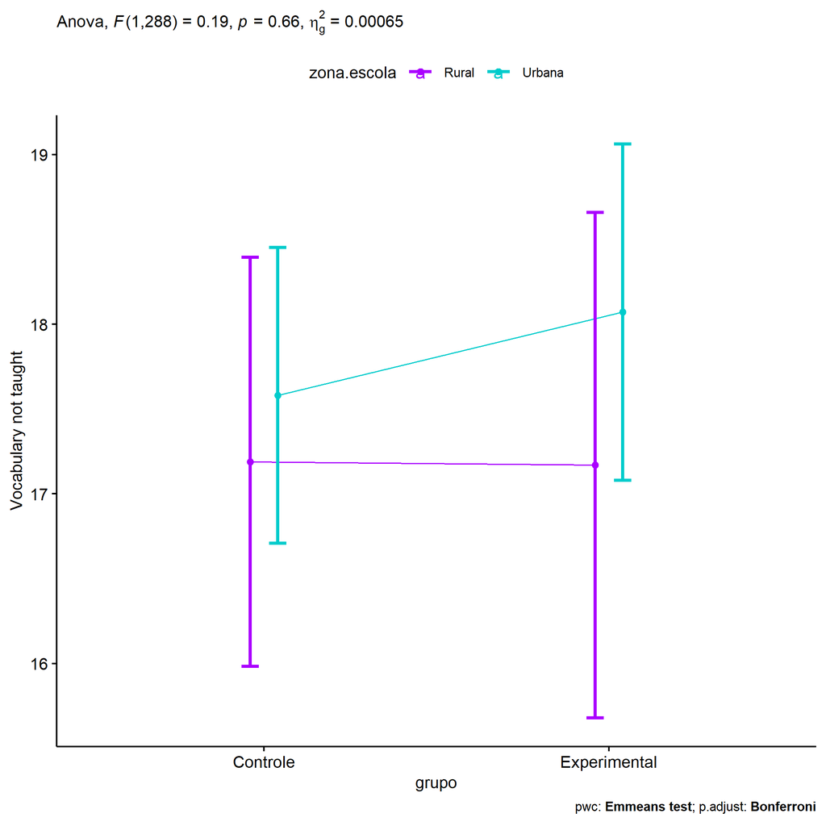

```r
if (length(unique(pdat[["zona.escola"]])) >= 2) {
  ggPlotAoC2(pwcs, "grupo", "zona.escola", aov, ylab = "Vocabulary not taught",
             subtitle = which(aov$Effect == "grupo:zona.escola"), addParam = "errorbar") +
    ggplot2::scale_color_manual(values = color[["zona.escola"]]) +
    ggplot2::ylab("Vocabulary not taught") +
    if (ymin.ci < ymax.ci) ggplot2::ylim(ymin.ci, ymax.ci)
}
```

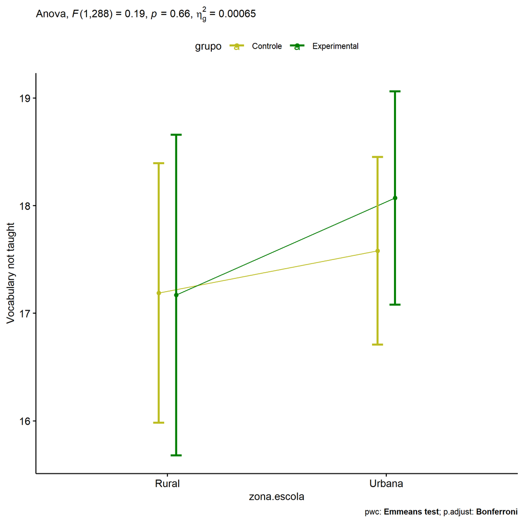

```r
if (length(unique(pdat[["zona.escola"]])) >= 2) {
  ggPlotAoC2(pwcs, "zona.escola", "grupo", aov, ylab = "Vocabulary not taught",
               subtitle = which(aov$Effect == "grupo:zona.escola"), addParam = "errorbar") +
    ggplot2::scale_color_manual(values = color[["grupo"]]) +
    ggplot2::ylab("Vocabulary not taught") +
    if (ymin.ci < ymax.ci) ggplot2::ylim(ymin.ci, ymax.ci)
}
```

```r
if (length(unique(pdat[["zona.escola"]])) >= 2) {
  plots <- twoWayAncovaBoxPlots(
    wdat, "score.vocab.nao.ensinado.pos", c("grupo","zona.escola"), aov, pwcs, covar = "score.vocab.nao.ensinado.pre",
    theme = "classic", color = color[["grupo:zona.escola"]],
    subtitle = which(aov$Effect == "grupo:zona.escola"))
}
```

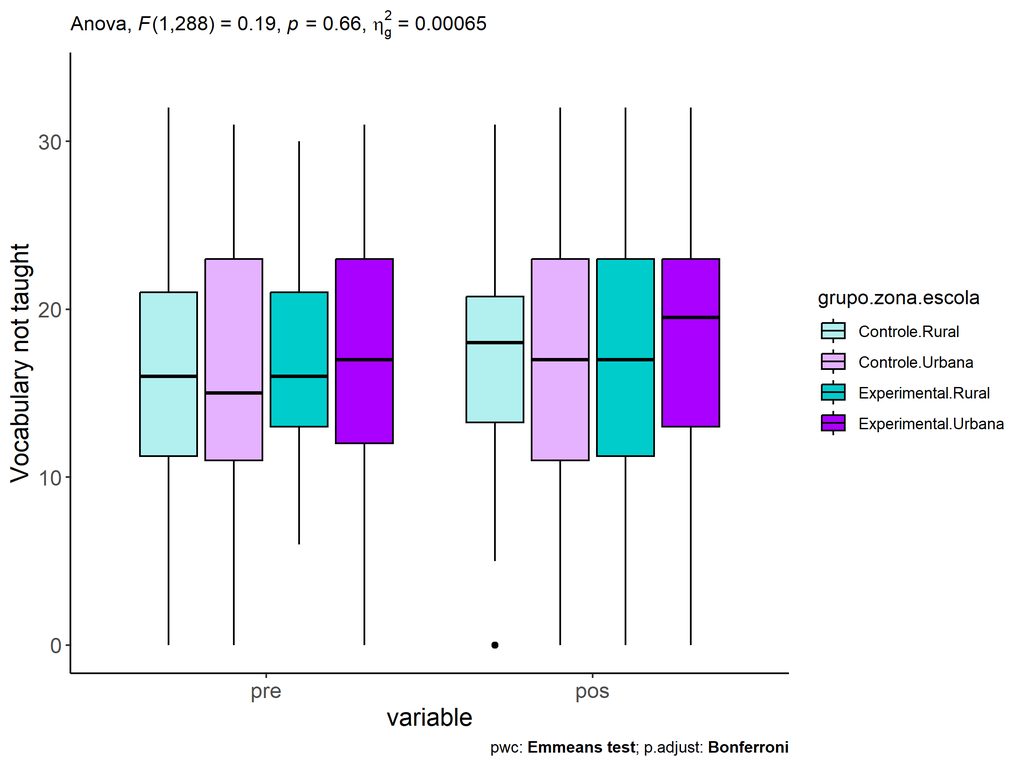

```r
if (length(unique(pdat[["zona.escola"]])) >= 2) {
  plots[["grupo:zona.escola"]] + ggplot2::ylab("Vocabulary not taught") +
  ggplot2::scale_x_discrete(labels=c('pre', 'pos')) +
  if (ymin < ymax) ggplot2::ylim(ymin, ymax)
}
```

```r
if (length(unique(pdat[["zona.escola"]])) >= 2) {
  plots <- twoWayAncovaBoxPlots(
    wdat.long, "score.vocab.nao.ensinado", c("grupo","zona.escola"), aov, pwc.long,
    pre.post = "time",
    theme = "classic", color = color$prepost)
}
```

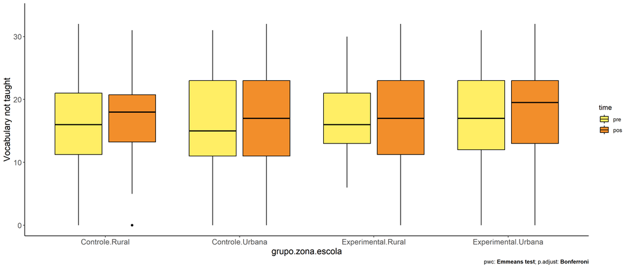

```r
if (length(unique(pdat[["zona.escola"]])) >= 2)
  plots[["grupo:zona.escola"]] + ggplot2::ylab("Vocabulary not taught") +
    if (ymin < ymax) ggplot2::ylim(ymin, ymax)
```

### Checking linearity assumption

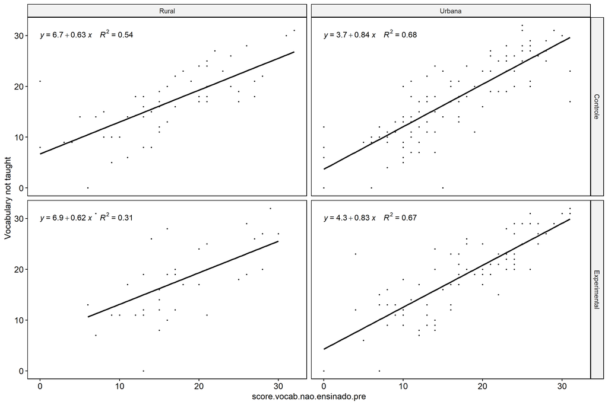

```r
if (length(unique(pdat[["zona.escola"]])) >= 2) {
  ggscatter(wdat, x = "score.vocab.nao.ensinado.pre", y = "score.vocab.nao.ensinado.pos", size = 0.5,
            facet.by = c("grupo","zona.escola"), add = "reg.line")+
    stat_regline_equation(
      aes(label =  paste(..eq.label.., ..rr.label.., sep = "~~~~"))
    ) + ggplot2::ylab("Vocabulary not taught") +
    if (ymin < ymax) ggplot2::ylim(ymin, ymax)
}
```

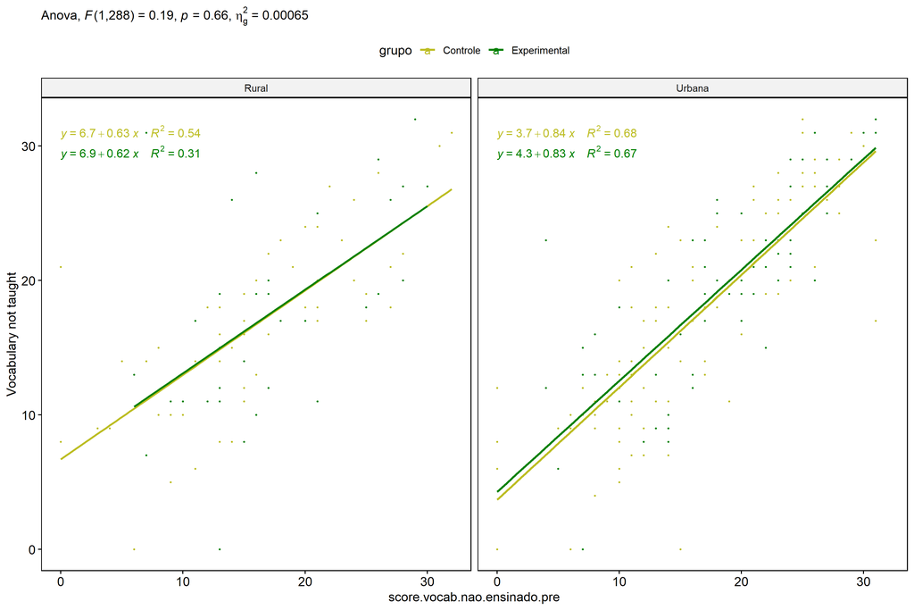

```r
if (length(unique(pdat[["zona.escola"]])) >= 2) {
  ggscatter(wdat, x = "score.vocab.nao.ensinado.pre", y = "score.vocab.nao.ensinado.pos", size = 0.5,
            color = "grupo", facet.by = "zona.escola", add = "reg.line")+
    stat_regline_equation(
      aes(label =  paste(..eq.label.., ..rr.label.., sep = "~~~~"), color = grupo)
    ) +
    ggplot2::labs(subtitle = rstatix::get_test_label(aov, detailed = T, row = which(aov$Effect == "grupo:zona.escola"))) +
    ggplot2::scale_color_manual(values = color[["grupo"]]) +
    ggplot2::ylab("Vocabulary not taught") +
    if (ymin < ymax) ggplot2::ylim(ymin, ymax)
}
```

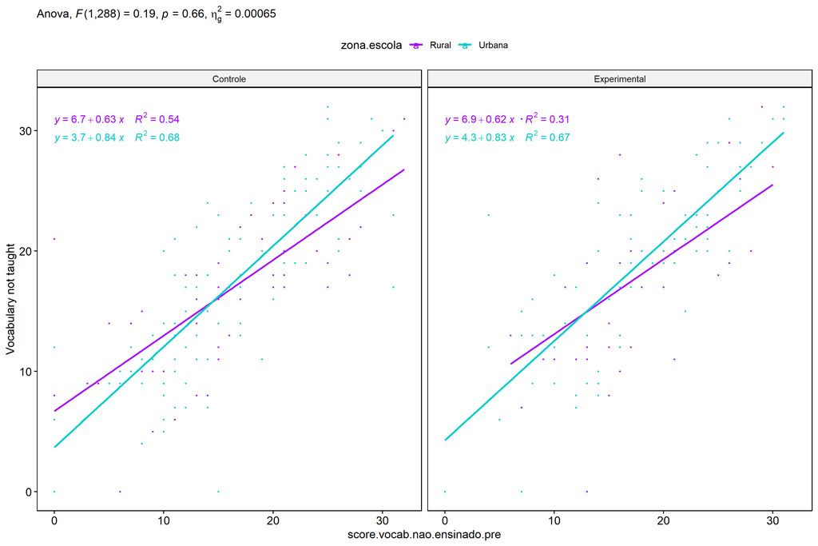

```r
if (length(unique(pdat[["zona.escola"]])) >= 2) {
  ggscatter(wdat, x = "score.vocab.nao.ensinado.pre", y = "score.vocab.nao.ensinado.pos", size = 0.5,
            color = "zona.escola", facet.by = "grupo", add = "reg.line")+
    stat_regline_equation(
      aes(label =  paste(..eq.label.., ..rr.label.., sep = "~~~~"), color = zona.escola)
    ) +
    ggplot2::labs(subtitle = rstatix::get_test_label(aov, detailed = T, row = which(aov$Effect == "grupo:zona.escola"))) +
    ggplot2::scale_color_manual(values = color[["zona.escola"]]) +
    ggplot2::ylab("Vocabulary not taught") +
    if (ymin < ymax) ggplot2::ylim(ymin, ymax)
}
```

### Checking normality and homogeneity

```r
if (length(unique(pdat[["zona.escola"]])) >= 2)
  res <- augment(lm(score.vocab.nao.ensinado.pos ~ score.vocab.nao.ensinado.pre + grupo*zona.escola, data = wdat))
```

```r
if (length(unique(pdat[["zona.escola"]])) >= 2)
  shapiro_test(res$.resid)
```

```
## # A tibble: 1 × 3
##   variable   statistic  p.value
##   <chr>          <dbl>    <dbl>
## 1 res$.resid     0.977 0.000108
```

```r
if (length(unique(pdat[["zona.escola"]])) >= 2)
  levene_test(res, .resid ~ grupo*zona.escola)
```

```
## # A tibble: 1 × 4
##     df1   df2 statistic     p
##   <int> <int>     <dbl> <dbl>
## 1     3   289      1.22 0.304
```

# ANCOVA and Pairwise for two factors **grupo:score.vocab.nao.ensinado.quintile**

## Without remove non-normal data

```r
pdat = remove_group_data(dat[!is.na(dat[["grupo"]]) & !is.na(dat[["score.vocab.nao.ensinado.quintile"]]),],
                         "score.vocab.nao.ensinado.pos", c("grupo","score.vocab.nao.ensinado.quintile"))
pdat = pdat[pdat[["score.vocab.nao.ensinado.quintile"]] %in% do.call(
  intersect, lapply(unique(pdat[["grupo"]]), FUN = function(x) {
    unique(pdat[["score.vocab.nao.ensinado.quintile"]][which(pdat[["grupo"]] == x)])
  })),]
pdat[["grupo"]] = factor(pdat[["grupo"]], level[["grupo"]])
pdat[["score.vocab.nao.ensinado.quintile"]] = factor(
  pdat[["score.vocab.nao.ensinado.quintile"]],
  level[["score.vocab.nao.ensinado.quintile"]][level[["score.vocab.nao.ensinado.quintile"]] %in% unique(pdat[["score.vocab.nao.ensinado.quintile"]])])

pdat.long <- rbind(pdat[,c("id","grupo","score.vocab.nao.ensinado.quintile")], pdat[,c("id","grupo","score.vocab.nao.ensinado.quintile")])
pdat.long[["time"]] <- c(rep("pre", nrow(pdat)), rep("pos", nrow(pdat)))
pdat.long[["time"]] <- factor(pdat.long[["time"]], c("pre","pos"))
pdat.long[["score.vocab.nao.ensinado"]] <- c(pdat[["score.vocab.nao.ensinado.pre"]], pdat[["score.vocab.nao.ensinado.pos"]])

if (length(unique(pdat[["score.vocab.nao.ensinado.quintile"]])) >= 2) {
  aov = anova_test(pdat, score.vocab.nao.ensinado.pos ~ score.vocab.nao.ensinado.pre + grupo*score.vocab.nao.ensinado.quintile)
  laov[["grupo:score.vocab.nao.ensinado.quintile"]] <- get_anova_table(aov)
}
```

```r
if (length(unique(pdat[["score.vocab.nao.ensinado.quintile"]])) >= 2) {
  pwcs <- list()
  pwcs[["score.vocab.nao.ensinado.quintile"]] <- emmeans_test(
    group_by(pdat, grupo), score.vocab.nao.ensinado.pos ~ score.vocab.nao.ensinado.quintile,
    covariate = score.vocab.nao.ensinado.pre, p.adjust.method = "bonferroni")
  pwcs[["grupo"]] <- emmeans_test(
    group_by(pdat, score.vocab.nao.ensinado.quintile), score.vocab.nao.ensinado.pos ~ grupo,
    covariate = score.vocab.nao.ensinado.pre, p.adjust.method = "bonferroni")

  pwc <- plyr::rbind.fill(pwcs[["grupo"]], pwcs[["score.vocab.nao.ensinado.quintile"]])
  pwc <- pwc[,c("grupo","score.vocab.nao.ensinado.quintile", colnames(pwc)[!colnames(pwc) %in% c("grupo","score.vocab.nao.ensinado.quintile")])]
}
```

```r
if (length(unique(pdat[["score.vocab.nao.ensinado.quintile"]])) >= 2) {
  pwc.long <- emmeans_test(dplyr::group_by_at(pdat.long, c("grupo","score.vocab.nao.ensinado.quintile")),
                           score.vocab.nao.ensinado ~ time,
                           p.adjust.method = "bonferroni")
  lpwc[["grupo:score.vocab.nao.ensinado.quintile"]] <- plyr::rbind.fill(pwc, pwc.long)
}
```

```r
if (length(unique(pdat[["score.vocab.nao.ensinado.quintile"]])) >= 2) {
  ds <- get.descriptives(pdat, "score.vocab.nao.ensinado.pos", c("grupo","score.vocab.nao.ensinado.quintile"), covar = "score.vocab.nao.ensinado.pre")
  ds <- merge(ds[ds$variable != "score.vocab.nao.ensinado.pre",],
              ds[ds$variable == "score.vocab.nao.ensinado.pre", !colnames(ds) %in% c("variable")],
              by = c("grupo","score.vocab.nao.ensinado.quintile"), all.x = T, suffixes = c("", ".score.vocab.nao.ensinado.pre"))
  ds <- merge(get_emmeans(pwcs[["grupo"]]), ds,
              by = c("grupo","score.vocab.nao.ensinado.quintile"), suffixes = c(".emms", ""))
  ds <- ds[,c("grupo","score.vocab.nao.ensinado.quintile","n","mean.score.vocab.nao.ensinado.pre","se.score.vocab.nao.ensinado.pre","mean","se",
              "emmean","se.emms","conf.low","conf.high")]

  colnames(ds) <- c("grupo","score.vocab.nao.ensinado.quintile", "N", paste0(c("M","SE")," (pre)"),
                    paste0(c("M","SE"), " (unadj)"),
                    paste0(c("M", "SE"), " (adj)"), "conf.low", "conf.high")

  lemms[["grupo:score.vocab.nao.ensinado.quintile"]] <- ds
}
```

## Computing ANCOVA and PairWise After removing non-normal data (OK)

```r
if (length(unique(pdat[["score.vocab.nao.ensinado.quintile"]])) >= 2) {
  wdat = pdat

  res = residuals(lm(score.vocab.nao.ensinado.pos ~ score.vocab.nao.ensinado.pre + grupo*score.vocab.nao.ensinado.quintile, data = wdat))
  non.normal = getNonNormal(res, wdat$id, plimit = 0.05)

  wdat = wdat[!wdat$id %in% non.normal,]

  wdat.long <- rbind(wdat[,c("id","grupo","score.vocab.nao.ensinado.quintile")], wdat[,c("id","grupo","score.vocab.nao.ensinado.quintile")])
  wdat.long[["time"]] <- c(rep("pre", nrow(wdat)), rep("pos", nrow(wdat)))
  wdat.long[["time"]] <- factor(wdat.long[["time"]], c("pre","pos"))
  wdat.long[["score.vocab.nao.ensinado"]] <- c(wdat[["score.vocab.nao.ensinado.pre"]], wdat[["score.vocab.nao.ensinado.pos"]])


  ldat[["grupo:score.vocab.nao.ensinado.quintile"]] = wdat

  (non.normal)
}
```

```
##  [1] "P187" "P314" "P20"  "P84"  "P37"  "P190" "P179" "P300" "P79"  "P323" "P202" "P204" "P294"
## [14] "P12"
```

```r
if (length(unique(pdat[["score.vocab.nao.ensinado.quintile"]])) >= 2) {
  aov = anova_test(wdat, score.vocab.nao.ensinado.pos ~ score.vocab.nao.ensinado.pre + grupo*score.vocab.nao.ensinado.quintile)
  laov[["grupo:score.vocab.nao.ensinado.quintile"]] <- merge(get_anova_table(aov), laov[["grupo:score.vocab.nao.ensinado.quintile"]],
                                         by="Effect", suffixes = c("","'"))
  df = get_anova_table(aov)
}
```

| Effect | DFn | DFd | F | p | p<.05 | ges |
| --- | --- | --- | --- | --- | --- | --- |
| score.vocab.nao.ensinado.pre | 1 | 286 | 15.071 | 0.000 | * | 0.050 |
| grupo | 1 | 286 | 0.718 | 0.397 |  | 0.003 |
| score.vocab.nao.ensinado.quintile | 4 | 286 | 5.715 | 0.000 | * | 0.074 |
| grupo:score.vocab.nao.ensinado.quintile | 4 | 286 | 3.284 | 0.012 | * | 0.044 |

```r
if (length(unique(pdat[["score.vocab.nao.ensinado.quintile"]])) >= 2) {
  pwcs <- list()
  pwcs[["score.vocab.nao.ensinado.quintile"]] <- emmeans_test(
    group_by(wdat, grupo), score.vocab.nao.ensinado.pos ~ score.vocab.nao.ensinado.quintile,
    covariate = score.vocab.nao.ensinado.pre, p.adjust.method = "bonferroni")
  pwcs[["grupo"]] <- emmeans_test(
    group_by(wdat, score.vocab.nao.ensinado.quintile), score.vocab.nao.ensinado.pos ~ grupo,
    covariate = score.vocab.nao.ensinado.pre, p.adjust.method = "bonferroni")

  pwc <- plyr::rbind.fill(pwcs[["grupo"]], pwcs[["score.vocab.nao.ensinado.quintile"]])
  pwc <- pwc[,c("grupo","score.vocab.nao.ensinado.quintile", colnames(pwc)[!colnames(pwc) %in% c("grupo","score.vocab.nao.ensinado.quintile")])]
}
```

| grupo | score.vocab.nao.ensinado.quintile | term | .y. | group1 | group2 | df | statistic | p | p.adj | p.adj.signif |
| --- | --- | --- | --- | --- | --- | --- | --- | --- | --- | --- |
|  | 1st quintile | score.vocab.nao.ensinado.pre*grupo | score.vocab.nao.ensinado.pos | Controle | Experimental | 286 | -2.994 | 0.003 | 0.003 | ** |
|  | 2nd quintile | score.vocab.nao.ensinado.pre*grupo | score.vocab.nao.ensinado.pos | Controle | Experimental | 286 | 0.945 | 0.345 | 0.345 | ns |
|  | 3rd quintile | score.vocab.nao.ensinado.pre*grupo | score.vocab.nao.ensinado.pos | Controle | Experimental | 286 | -0.795 | 0.427 | 0.427 | ns |
|  | 4th quintile | score.vocab.nao.ensinado.pre*grupo | score.vocab.nao.ensinado.pos | Controle | Experimental | 286 | 1.090 | 0.277 | 0.277 | ns |
|  | 5th quintile | score.vocab.nao.ensinado.pre*grupo | score.vocab.nao.ensinado.pos | Controle | Experimental | 286 | -1.468 | 0.143 | 0.143 | ns |
| Controle |  | score.vocab.nao.ensinado.pre*score.vocab.nao.ensinado.quintile | score.vocab.nao.ensinado.pos | 1st quintile | 2nd quintile | 286 | 0.625 | 0.533 | 1.000 | ns |
| Controle |  | score.vocab.nao.ensinado.pre*score.vocab.nao.ensinado.quintile | score.vocab.nao.ensinado.pos | 1st quintile | 3rd quintile | 286 | 0.006 | 0.995 | 1.000 | ns |
| Controle |  | score.vocab.nao.ensinado.pre*score.vocab.nao.ensinado.quintile | score.vocab.nao.ensinado.pos | 1st quintile | 4th quintile | 286 | -1.000 | 0.318 | 1.000 | ns |
| Controle |  | score.vocab.nao.ensinado.pre*score.vocab.nao.ensinado.quintile | score.vocab.nao.ensinado.pos | 1st quintile | 5th quintile | 286 | -0.417 | 0.677 | 1.000 | ns |
| Controle |  | score.vocab.nao.ensinado.pre*score.vocab.nao.ensinado.quintile | score.vocab.nao.ensinado.pos | 2nd quintile | 3rd quintile | 286 | -0.778 | 0.437 | 1.000 | ns |
| Controle |  | score.vocab.nao.ensinado.pre*score.vocab.nao.ensinado.quintile | score.vocab.nao.ensinado.pos | 2nd quintile | 4th quintile | 286 | -2.018 | 0.045 | 0.445 | ns |
| Controle |  | score.vocab.nao.ensinado.pre*score.vocab.nao.ensinado.quintile | score.vocab.nao.ensinado.pos | 2nd quintile | 5th quintile | 286 | -0.904 | 0.367 | 1.000 | ns |
| Controle |  | score.vocab.nao.ensinado.pre*score.vocab.nao.ensinado.quintile | score.vocab.nao.ensinado.pos | 3rd quintile | 4th quintile | 286 | -2.199 | 0.029 | 0.287 | ns |
| Controle |  | score.vocab.nao.ensinado.pre*score.vocab.nao.ensinado.quintile | score.vocab.nao.ensinado.pos | 3rd quintile | 5th quintile | 286 | -0.726 | 0.469 | 1.000 | ns |
| Controle |  | score.vocab.nao.ensinado.pre*score.vocab.nao.ensinado.quintile | score.vocab.nao.ensinado.pos | 4th quintile | 5th quintile | 286 | 0.846 | 0.398 | 1.000 | ns |
| Experimental |  | score.vocab.nao.ensinado.pre*score.vocab.nao.ensinado.quintile | score.vocab.nao.ensinado.pos | 1st quintile | 2nd quintile | 286 | 3.831 | 0.000 | 0.002 | ** |
| Experimental |  | score.vocab.nao.ensinado.pre*score.vocab.nao.ensinado.quintile | score.vocab.nao.ensinado.pos | 1st quintile | 3rd quintile | 286 | 1.838 | 0.067 | 0.672 | ns |
| Experimental |  | score.vocab.nao.ensinado.pre*score.vocab.nao.ensinado.quintile | score.vocab.nao.ensinado.pos | 1st quintile | 4th quintile | 286 | 1.057 | 0.292 | 1.000 | ns |
| Experimental |  | score.vocab.nao.ensinado.pre*score.vocab.nao.ensinado.quintile | score.vocab.nao.ensinado.pos | 1st quintile | 5th quintile | 286 | 0.224 | 0.823 | 1.000 | ns |
| Experimental |  | score.vocab.nao.ensinado.pre*score.vocab.nao.ensinado.quintile | score.vocab.nao.ensinado.pos | 2nd quintile | 3rd quintile | 286 | -2.033 | 0.043 | 0.429 | ns |
| Experimental |  | score.vocab.nao.ensinado.pre*score.vocab.nao.ensinado.quintile | score.vocab.nao.ensinado.pos | 2nd quintile | 4th quintile | 286 | -1.799 | 0.073 | 0.731 | ns |
| Experimental |  | score.vocab.nao.ensinado.pre*score.vocab.nao.ensinado.quintile | score.vocab.nao.ensinado.pos | 2nd quintile | 5th quintile | 286 | -2.177 | 0.030 | 0.303 | ns |
| Experimental |  | score.vocab.nao.ensinado.pre*score.vocab.nao.ensinado.quintile | score.vocab.nao.ensinado.pos | 3rd quintile | 4th quintile | 286 | -0.682 | 0.496 | 1.000 | ns |
| Experimental |  | score.vocab.nao.ensinado.pre*score.vocab.nao.ensinado.quintile | score.vocab.nao.ensinado.pos | 3rd quintile | 5th quintile | 286 | -1.579 | 0.115 | 1.000 | ns |
| Experimental |  | score.vocab.nao.ensinado.pre*score.vocab.nao.ensinado.quintile | score.vocab.nao.ensinado.pos | 4th quintile | 5th quintile | 286 | -1.450 | 0.148 | 1.000 | ns |

```r
if (length(unique(pdat[["score.vocab.nao.ensinado.quintile"]])) >= 2) {
  pwc.long <- emmeans_test(dplyr::group_by_at(wdat.long, c("grupo","score.vocab.nao.ensinado.quintile")),
                           score.vocab.nao.ensinado ~ time,
                           p.adjust.method = "bonferroni")
  lpwc[["grupo:score.vocab.nao.ensinado.quintile"]] <- merge(plyr::rbind.fill(pwc, pwc.long),
                                         lpwc[["grupo:score.vocab.nao.ensinado.quintile"]],
                                         by=c("grupo","score.vocab.nao.ensinado.quintile","term",".y.","group1","group2"),
                                         suffixes = c("","'"))
}
```

| grupo | score.vocab.nao.ensinado.quintile | term | .y. | group1 | group2 | df | statistic | p | p.adj | p.adj.signif |
| --- | --- | --- | --- | --- | --- | --- | --- | --- | --- | --- |
| Controle | 1st quintile | time | score.vocab.nao.ensinado | pre | pos | 574 | -4.856 | 0.000 | 0.000 | **** |
| Controle | 2nd quintile | time | score.vocab.nao.ensinado | pre | pos | 574 | -2.017 | 0.044 | 0.044 | * |
| Controle | 3rd quintile | time | score.vocab.nao.ensinado | pre | pos | 574 | -0.224 | 0.823 | 0.823 | ns |
| Controle | 4th quintile | time | score.vocab.nao.ensinado | pre | pos | 574 | -0.582 | 0.561 | 0.561 | ns |
| Controle | 5th quintile | time | score.vocab.nao.ensinado | pre | pos | 574 | 2.359 | 0.019 | 0.019 | * |
| Experimental | 1st quintile | time | score.vocab.nao.ensinado | pre | pos | 574 | -6.902 | 0.000 | 0.000 | **** |
| Experimental | 2nd quintile | time | score.vocab.nao.ensinado | pre | pos | 574 | -0.437 | 0.663 | 0.663 | ns |
| Experimental | 3rd quintile | time | score.vocab.nao.ensinado | pre | pos | 574 | -1.050 | 0.294 | 0.294 | ns |
| Experimental | 4th quintile | time | score.vocab.nao.ensinado | pre | pos | 574 | 0.888 | 0.375 | 0.375 | ns |
| Experimental | 5th quintile | time | score.vocab.nao.ensinado | pre | pos | 574 | 0.344 | 0.731 | 0.731 | ns |

```r
if (length(unique(pdat[["score.vocab.nao.ensinado.quintile"]])) >= 2) {
  ds <- get.descriptives(wdat, "score.vocab.nao.ensinado.pos", c("grupo","score.vocab.nao.ensinado.quintile"), covar = "score.vocab.nao.ensinado.pre")
  ds <- merge(ds[ds$variable != "score.vocab.nao.ensinado.pre",],
              ds[ds$variable == "score.vocab.nao.ensinado.pre", !colnames(ds) %in% c("variable")],
              by = c("grupo","score.vocab.nao.ensinado.quintile"), all.x = T, suffixes = c("", ".score.vocab.nao.ensinado.pre"))
  ds <- merge(get_emmeans(pwcs[["grupo"]]), ds,
              by = c("grupo","score.vocab.nao.ensinado.quintile"), suffixes = c(".emms", ""))
  ds <- ds[,c("grupo","score.vocab.nao.ensinado.quintile","n","mean.score.vocab.nao.ensinado.pre","se.score.vocab.nao.ensinado.pre",
              "mean","se","emmean","se.emms","conf.low","conf.high")]

  colnames(ds) <- c("grupo","score.vocab.nao.ensinado.quintile", "N", paste0(c("M","SE")," (pre)"),
                    paste0(c("M","SE"), " (unadj)"),
                    paste0(c("M", "SE"), " (adj)"), "conf.low", "conf.high")

  lemms[["grupo:score.vocab.nao.ensinado.quintile"]] <- merge(ds, lemms[["grupo:score.vocab.nao.ensinado.quintile"]],
                                          by=c("grupo","score.vocab.nao.ensinado.quintile"), suffixes = c("","'"))
}
```

| grupo | score.vocab.nao.ensinado.quintile | N | M (pre) | SE (pre) | M (unadj) | SE (unadj) | M (adj) | SE (adj) | conf.low | conf.high |
| --- | --- | --- | --- | --- | --- | --- | --- | --- | --- | --- |
| Controle | 1st quintile | 21 | 3.571 | 0.660 | 9.333 | 1.363 | 16.709 | 2.185 | 12.409 | 21.009 |
| Controle | 2nd quintile | 48 | 10.854 | 0.240 | 12.438 | 0.653 | 15.661 | 1.095 | 13.507 | 17.816 |
| Controle | 3rd quintile | 43 | 16.512 | 0.311 | 16.698 | 0.764 | 16.696 | 0.754 | 15.212 | 18.179 |
| Controle | 4th quintile | 44 | 23.250 | 0.274 | 23.727 | 0.588 | 19.884 | 1.239 | 17.445 | 22.323 |
| Controle | 5th quintile | 14 | 28.929 | 0.462 | 25.500 | 1.252 | 18.419 | 2.252 | 13.986 | 22.851 |
| Experimental | 1st quintile | 12 | 4.250 | 0.818 | 15.083 | 2.607 | 22.072 | 2.297 | 17.551 | 26.593 |
| Experimental | 2nd quintile | 30 | 11.000 | 0.329 | 11.433 | 0.776 | 14.574 | 1.212 | 12.189 | 16.959 |
| Experimental | 3rd quintile | 42 | 16.881 | 0.311 | 17.762 | 0.927 | 17.550 | 0.765 | 16.045 | 19.054 |
| Experimental | 4th quintile | 29 | 23.448 | 0.324 | 22.552 | 0.847 | 18.595 | 1.371 | 15.896 | 21.295 |
| Experimental | 5th quintile | 14 | 28.500 | 0.403 | 28.000 | 0.858 | 21.163 | 2.201 | 16.830 | 25.496 |

### Plots for ancova

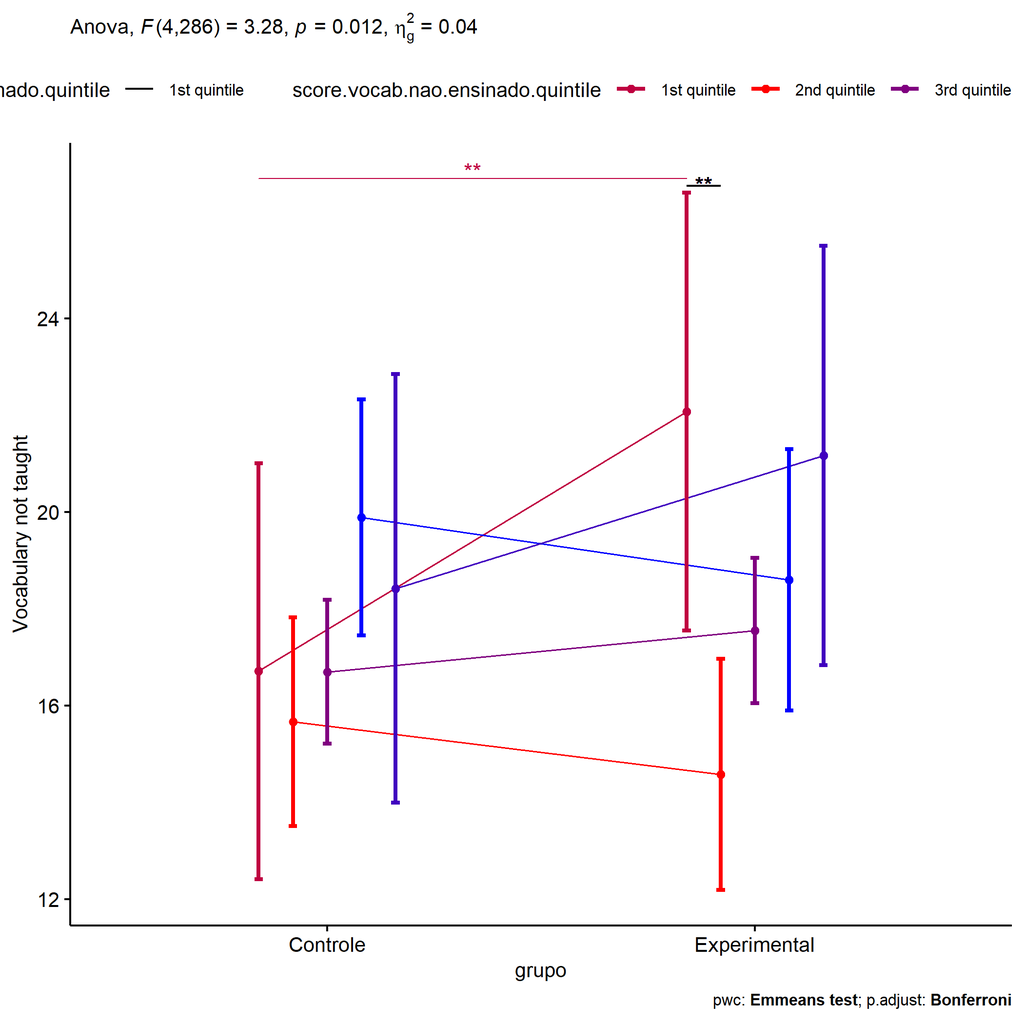

```r
if (length(unique(pdat[["score.vocab.nao.ensinado.quintile"]])) >= 2) {
  ggPlotAoC2(pwcs, "grupo", "score.vocab.nao.ensinado.quintile", aov, ylab = "Vocabulary not taught",
             subtitle = which(aov$Effect == "grupo:score.vocab.nao.ensinado.quintile"), addParam = "errorbar") +
    ggplot2::scale_color_manual(values = color[["score.vocab.nao.ensinado.quintile"]]) +
    ggplot2::ylab("Vocabulary not taught") +
    if (ymin.ci < ymax.ci) ggplot2::ylim(ymin.ci, ymax.ci)
}
```

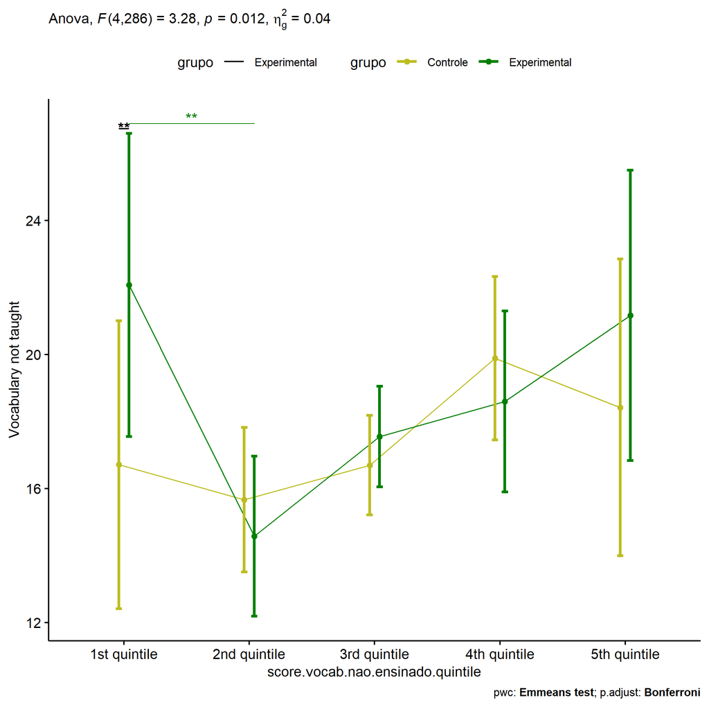

```r
if (length(unique(pdat[["score.vocab.nao.ensinado.quintile"]])) >= 2) {
  ggPlotAoC2(pwcs, "score.vocab.nao.ensinado.quintile", "grupo", aov, ylab = "Vocabulary not taught",
               subtitle = which(aov$Effect == "grupo:score.vocab.nao.ensinado.quintile"), addParam = "errorbar") +
    ggplot2::scale_color_manual(values = color[["grupo"]]) +
    ggplot2::ylab("Vocabulary not taught") +
    if (ymin.ci < ymax.ci) ggplot2::ylim(ymin.ci, ymax.ci)
}
```

```r
if (length(unique(pdat[["score.vocab.nao.ensinado.quintile"]])) >= 2) {
  plots <- twoWayAncovaBoxPlots(
    wdat, "score.vocab.nao.ensinado.pos", c("grupo","score.vocab.nao.ensinado.quintile"), aov, pwcs, covar = "score.vocab.nao.ensinado.pre",
    theme = "classic", color = color[["grupo:score.vocab.nao.ensinado.quintile"]],
    subtitle = which(aov$Effect == "grupo:score.vocab.nao.ensinado.quintile"))
}
```

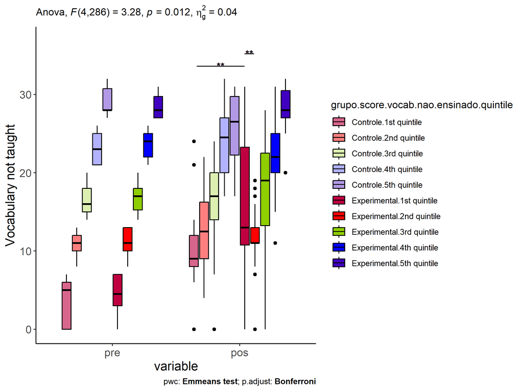

```r
if (length(unique(pdat[["score.vocab.nao.ensinado.quintile"]])) >= 2) {
  plots[["grupo:score.vocab.nao.ensinado.quintile"]] + ggplot2::ylab("Vocabulary not taught") +
  ggplot2::scale_x_discrete(labels=c('pre', 'pos')) +
  if (ymin < ymax) ggplot2::ylim(ymin, ymax)
}
```

```r
if (length(unique(pdat[["score.vocab.nao.ensinado.quintile"]])) >= 2) {
  plots <- twoWayAncovaBoxPlots(
    wdat.long, "score.vocab.nao.ensinado", c("grupo","score.vocab.nao.ensinado.quintile"), aov, pwc.long,
    pre.post = "time",
    theme = "classic", color = color$prepost)
}
```

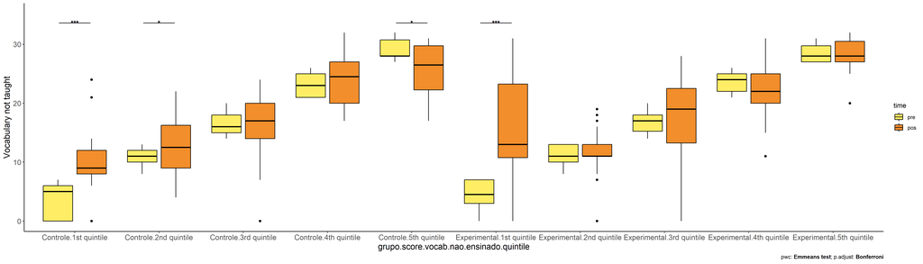

```r
if (length(unique(pdat[["score.vocab.nao.ensinado.quintile"]])) >= 2)
  plots[["grupo:score.vocab.nao.ensinado.quintile"]] + ggplot2::ylab("Vocabulary not taught") +
    if (ymin < ymax) ggplot2::ylim(ymin, ymax)
```

### Checking linearity assumption

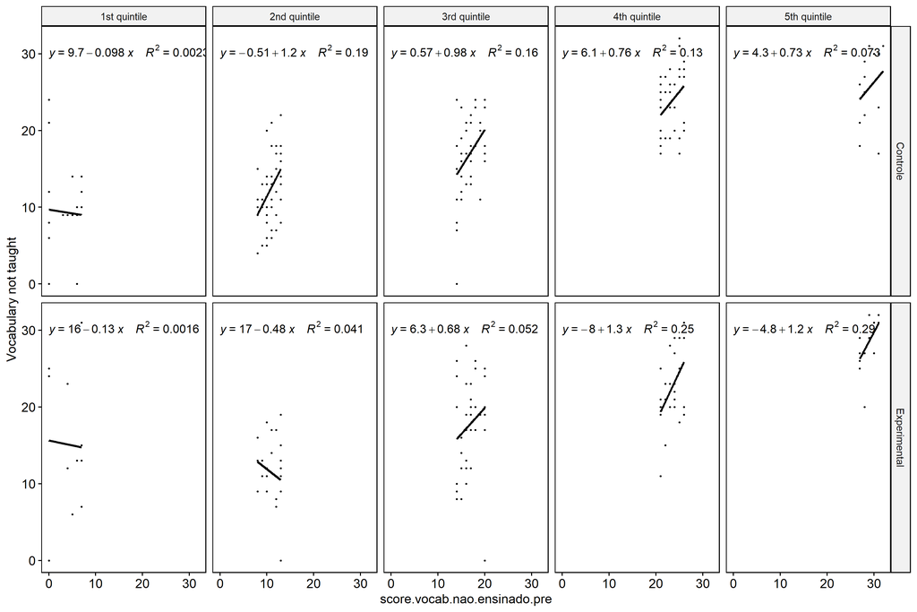

```r
if (length(unique(pdat[["score.vocab.nao.ensinado.quintile"]])) >= 2) {
  ggscatter(wdat, x = "score.vocab.nao.ensinado.pre", y = "score.vocab.nao.ensinado.pos", size = 0.5,
            facet.by = c("grupo","score.vocab.nao.ensinado.quintile"), add = "reg.line")+
    stat_regline_equation(
      aes(label =  paste(..eq.label.., ..rr.label.., sep = "~~~~"))
    ) + ggplot2::ylab("Vocabulary not taught") +
    if (ymin < ymax) ggplot2::ylim(ymin, ymax)
}
```

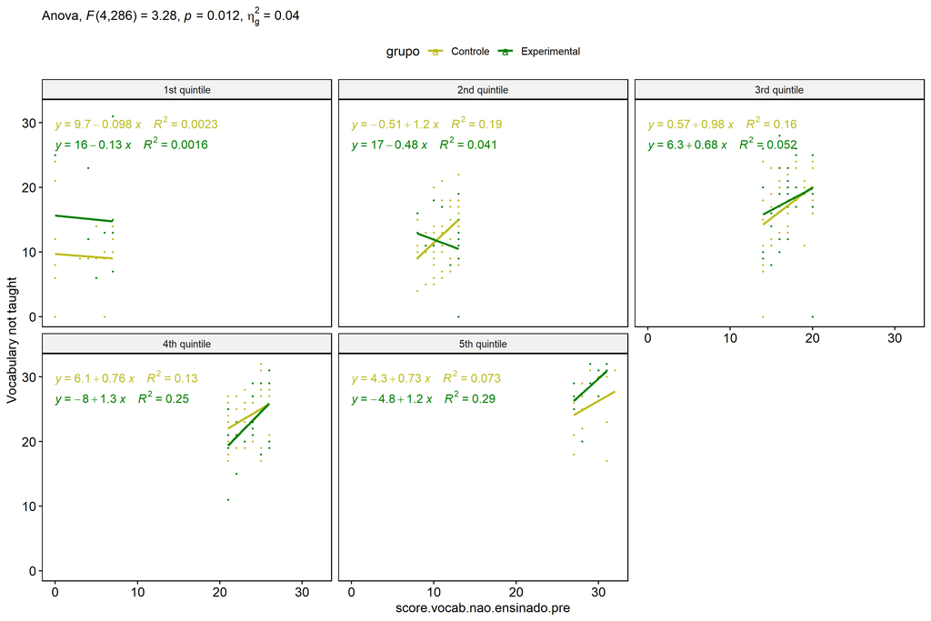

```r
if (length(unique(pdat[["score.vocab.nao.ensinado.quintile"]])) >= 2) {
  ggscatter(wdat, x = "score.vocab.nao.ensinado.pre", y = "score.vocab.nao.ensinado.pos", size = 0.5,
            color = "grupo", facet.by = "score.vocab.nao.ensinado.quintile", add = "reg.line")+
    stat_regline_equation(
      aes(label =  paste(..eq.label.., ..rr.label.., sep = "~~~~"), color = grupo)
    ) +
    ggplot2::labs(subtitle = rstatix::get_test_label(aov, detailed = T, row = which(aov$Effect == "grupo:score.vocab.nao.ensinado.quintile"))) +
    ggplot2::scale_color_manual(values = color[["grupo"]]) +
    ggplot2::ylab("Vocabulary not taught") +
    if (ymin < ymax) ggplot2::ylim(ymin, ymax)
}
```

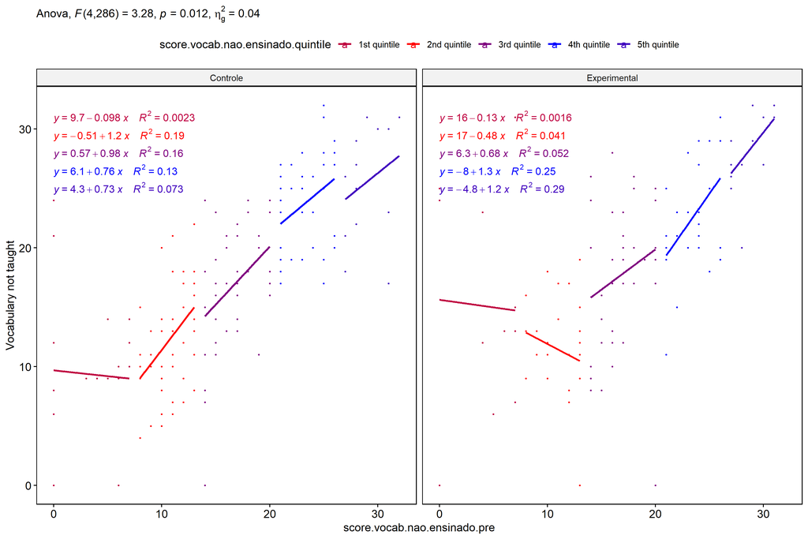

```r
if (length(unique(pdat[["score.vocab.nao.ensinado.quintile"]])) >= 2) {
  ggscatter(wdat, x = "score.vocab.nao.ensinado.pre", y = "score.vocab.nao.ensinado.pos", size = 0.5,
            color = "score.vocab.nao.ensinado.quintile", facet.by = "grupo", add = "reg.line")+
    stat_regline_equation(
      aes(label =  paste(..eq.label.., ..rr.label.., sep = "~~~~"), color = score.vocab.nao.ensinado.quintile)
    ) +
    ggplot2::labs(subtitle = rstatix::get_test_label(aov, detailed = T, row = which(aov$Effect == "grupo:score.vocab.nao.ensinado.quintile"))) +
    ggplot2::scale_color_manual(values = color[["score.vocab.nao.ensinado.quintile"]]) +
    ggplot2::ylab("Vocabulary not taught") +
    if (ymin < ymax) ggplot2::ylim(ymin, ymax)
}
```

### Checking normality and homogeneity

```r
if (length(unique(pdat[["score.vocab.nao.ensinado.quintile"]])) >= 2)
  res <- augment(lm(score.vocab.nao.ensinado.pos ~ score.vocab.nao.ensinado.pre + grupo*score.vocab.nao.ensinado.quintile, data = wdat))
```

```r
if (length(unique(pdat[["score.vocab.nao.ensinado.quintile"]])) >= 2)
  shapiro_test(res$.resid)
```

```
## # A tibble: 1 × 3
##   variable   statistic p.value
##   <chr>          <dbl>   <dbl>
## 1 res$.resid     0.987 0.00811
```

```r
if (length(unique(pdat[["score.vocab.nao.ensinado.quintile"]])) >= 2)
  levene_test(res, .resid ~ grupo*score.vocab.nao.ensinado.quintile)
```

```
## # A tibble: 1 × 4
##     df1   df2 statistic      p
##   <int> <int>     <dbl>  <dbl>
## 1     9   287      2.37 0.0134
```

# Summary of Results

## Descriptive Statistics

```r
df <- get.descriptives(ldat[["grupo"]], c(dv.pre, dv.pos), c("grupo"),
                       include.global = T, symmetry.test = T, normality.test = F)
df <- plyr::rbind.fill(
  df, do.call(plyr::rbind.fill, lapply(lfatores2, FUN = function(f) {
    if (nrow(dat) > 0 && sum(!is.na(unique(dat[[f]]))) > 1 && paste0("grupo:",f) %in% names(ldat))
      get.descriptives(ldat[[paste0("grupo:",f)]], c(dv.pre,dv.pos), c("grupo", f),
                       symmetry.test = T, normality.test = F)
    }))
)
df <- df[,c(fatores1[fatores1 %in% colnames(df)],"variable",
             colnames(df)[!colnames(df) %in% c(fatores1,"variable")])]
```

| grupo | genero | zona.participante | zona.escola | score.vocab.nao.ensinado.quintile | variable | n | mean | median | min | max | sd | se | ci | iqr | symmetry | skewness | kurtosis |
| --- | --- | --- | --- | --- | --- | --- | --- | --- | --- | --- | --- | --- | --- | --- | --- | --- | --- |
| Controle |  |  |  |  | score.vocab.nao.ensinado.pre | 170 | 16.171 | 15.5 | 0 | 32 | 7.532 | 0.578 | 1.140 | 11.00 | YES | -0.063 | -0.674 |
| Experimental |  |  |  |  | score.vocab.nao.ensinado.pre | 123 | 17.260 | 17.0 | 0 | 31 | 7.137 | 0.643 | 1.274 | 10.50 | YES | -0.104 | -0.703 |
|  |  |  |  |  | score.vocab.nao.ensinado.pre | 293 | 16.628 | 16.0 | 0 | 32 | 7.376 | 0.431 | 0.848 | 12.00 | YES | -0.090 | -0.661 |
| Controle |  |  |  |  | score.vocab.nao.ensinado.pos | 170 | 16.988 | 17.0 | 0 | 32 | 7.385 | 0.566 | 1.118 | 12.00 | YES | -0.166 | -0.550 |
| Experimental |  |  |  |  | score.vocab.nao.ensinado.pos | 123 | 18.374 | 19.0 | 0 | 32 | 7.090 | 0.639 | 1.266 | 11.50 | YES | -0.087 | -0.678 |
|  |  |  |  |  | score.vocab.nao.ensinado.pos | 293 | 17.570 | 18.0 | 0 | 32 | 7.282 | 0.425 | 0.837 | 11.00 | YES | -0.145 | -0.552 |
| Controle | F |  |  |  | score.vocab.nao.ensinado.pre | 83 | 17.133 | 17.0 | 0 | 31 | 7.014 | 0.770 | 1.531 | 11.00 | YES | -0.140 | -0.641 |
| Controle | M |  |  |  | score.vocab.nao.ensinado.pre | 86 | 15.256 | 14.0 | 0 | 32 | 7.974 | 0.860 | 1.710 | 11.00 | YES | 0.060 | -0.773 |
| Experimental | F |  |  |  | score.vocab.nao.ensinado.pre | 55 | 18.873 | 20.0 | 0 | 31 | 7.268 | 0.980 | 1.965 | 10.50 | YES | -0.375 | -0.544 |
| Experimental | M |  |  |  | score.vocab.nao.ensinado.pre | 68 | 16.147 | 16.0 | 4 | 30 | 6.527 | 0.792 | 1.580 | 10.25 | YES | 0.208 | -0.813 |
| Controle | F |  |  |  | score.vocab.nao.ensinado.pos | 83 | 18.398 | 18.0 | 0 | 32 | 6.294 | 0.691 | 1.374 | 9.00 | YES | -0.108 | -0.203 |
| Controle | M |  |  |  | score.vocab.nao.ensinado.pos | 86 | 15.826 | 16.0 | 0 | 31 | 7.969 | 0.859 | 1.709 | 12.50 | YES | 0.017 | -0.912 |
| Experimental | F |  |  |  | score.vocab.nao.ensinado.pos | 55 | 19.509 | 21.0 | 0 | 32 | 8.262 | 1.114 | 2.233 | 12.50 | NO | -0.560 | -0.399 |
| Experimental | M |  |  |  | score.vocab.nao.ensinado.pos | 68 | 17.103 | 17.0 | 7 | 31 | 6.196 | 0.751 | 1.500 | 9.25 | YES | 0.279 | -0.841 |
| Controle |  | Rural |  |  | score.vocab.nao.ensinado.pre | 56 | 15.304 | 14.0 | 0 | 31 | 7.608 | 1.017 | 2.038 | 11.00 | YES | -0.046 | -0.741 |
| Controle |  | Urbana |  |  | score.vocab.nao.ensinado.pre | 73 | 17.068 | 17.0 | 0 | 32 | 7.321 | 0.857 | 1.708 | 11.00 | YES | -0.244 | -0.455 |
| Experimental |  | Rural |  |  | score.vocab.nao.ensinado.pre | 50 | 16.380 | 16.0 | 4 | 31 | 6.889 | 0.974 | 1.958 | 9.00 | YES | 0.198 | -0.733 |
| Experimental |  | Urbana |  |  | score.vocab.nao.ensinado.pre | 47 | 18.362 | 20.0 | 0 | 31 | 7.188 | 1.049 | 2.111 | 10.00 | YES | -0.401 | -0.632 |
| Controle |  | Rural |  |  | score.vocab.nao.ensinado.pos | 56 | 16.929 | 17.0 | 6 | 31 | 6.361 | 0.850 | 1.704 | 10.25 | YES | 0.142 | -0.946 |
| Controle |  | Urbana |  |  | score.vocab.nao.ensinado.pos | 73 | 17.781 | 18.0 | 0 | 32 | 7.364 | 0.862 | 1.718 | 10.00 | YES | -0.228 | -0.539 |
| Experimental |  | Rural |  |  | score.vocab.nao.ensinado.pos | 50 | 19.160 | 19.0 | 7 | 32 | 6.554 | 0.927 | 1.863 | 11.00 | YES | 0.162 | -1.073 |
| Experimental |  | Urbana |  |  | score.vocab.nao.ensinado.pos | 47 | 18.128 | 20.0 | 0 | 32 | 8.085 | 1.179 | 2.374 | 12.50 | YES | -0.270 | -0.738 |
| Controle |  |  | Rural |  | score.vocab.nao.ensinado.pre | 58 | 16.379 | 16.0 | 0 | 32 | 7.504 | 0.985 | 1.973 | 9.75 | YES | -0.155 | -0.590 |
| Controle |  |  | Urbana |  | score.vocab.nao.ensinado.pre | 111 | 16.081 | 15.0 | 0 | 31 | 7.610 | 0.722 | 1.431 | 12.00 | YES | -0.022 | -0.768 |
| Experimental |  |  | Rural |  | score.vocab.nao.ensinado.pre | 38 | 17.079 | 16.0 | 6 | 30 | 6.606 | 1.072 | 2.171 | 8.00 | YES | 0.365 | -0.872 |
| Experimental |  |  | Urbana |  | score.vocab.nao.ensinado.pre | 86 | 17.372 | 17.0 | 0 | 31 | 7.213 | 0.778 | 1.546 | 11.00 | YES | -0.164 | -0.826 |
| Controle |  |  | Rural |  | score.vocab.nao.ensinado.pos | 58 | 16.983 | 18.0 | 0 | 31 | 6.381 | 0.838 | 1.678 | 7.50 | YES | -0.178 | -0.182 |
| Controle |  |  | Urbana |  | score.vocab.nao.ensinado.pos | 111 | 17.144 | 17.0 | 0 | 32 | 7.748 | 0.735 | 1.457 | 12.00 | YES | -0.133 | -0.782 |
| Experimental |  |  | Rural |  | score.vocab.nao.ensinado.pos | 38 | 17.500 | 17.0 | 0 | 32 | 7.417 | 1.203 | 2.438 | 11.75 | YES | 0.116 | -0.651 |
| Experimental |  |  | Urbana |  | score.vocab.nao.ensinado.pos | 86 | 18.628 | 19.5 | 0 | 32 | 7.299 | 0.787 | 1.565 | 10.00 | YES | -0.241 | -0.570 |
| Controle |  |  |  | 1st quintile | score.vocab.nao.ensinado.pre | 21 | 3.571 | 5.0 | 0 | 7 | 3.026 | 0.660 | 1.377 | 6.00 | YES | -0.216 | -1.843 |
| Controle |  |  |  | 2nd quintile | score.vocab.nao.ensinado.pre | 48 | 10.854 | 11.0 | 8 | 13 | 1.663 | 0.240 | 0.483 | 2.00 | YES | -0.235 | -1.104 |
| Controle |  |  |  | 3rd quintile | score.vocab.nao.ensinado.pre | 43 | 16.512 | 16.0 | 14 | 20 | 2.040 | 0.311 | 0.628 | 3.00 | YES | 0.395 | -1.101 |
| Controle |  |  |  | 4th quintile | score.vocab.nao.ensinado.pre | 44 | 23.250 | 23.0 | 21 | 26 | 1.819 | 0.274 | 0.553 | 4.00 | YES | 0.044 | -1.439 |
| Controle |  |  |  | 5th quintile | score.vocab.nao.ensinado.pre | 14 | 28.929 | 28.0 | 27 | 32 | 1.730 | 0.462 | 0.999 | 2.75 | YES | 0.432 | -1.480 |
| Experimental |  |  |  | 1st quintile | score.vocab.nao.ensinado.pre | 12 | 4.250 | 4.5 | 0 | 7 | 2.832 | 0.818 | 1.800 | 4.00 | NO | -0.518 | -1.424 |
| Experimental |  |  |  | 2nd quintile | score.vocab.nao.ensinado.pre | 30 | 11.000 | 11.0 | 8 | 13 | 1.800 | 0.329 | 0.672 | 3.00 | YES | -0.206 | -1.483 |
| Experimental |  |  |  | 3rd quintile | score.vocab.nao.ensinado.pre | 42 | 16.881 | 17.0 | 14 | 20 | 2.015 | 0.311 | 0.628 | 2.75 | YES | 0.246 | -1.143 |
| Experimental |  |  |  | 4th quintile | score.vocab.nao.ensinado.pre | 29 | 23.448 | 24.0 | 21 | 26 | 1.744 | 0.324 | 0.663 | 3.00 | YES | -0.014 | -1.289 |
| Experimental |  |  |  | 5th quintile | score.vocab.nao.ensinado.pre | 14 | 28.500 | 28.0 | 27 | 31 | 1.506 | 0.403 | 0.870 | 2.75 | YES | 0.439 | -1.420 |
| Controle |  |  |  | 1st quintile | score.vocab.nao.ensinado.pos | 21 | 9.333 | 9.0 | 0 | 24 | 6.248 | 1.363 | 2.844 | 4.00 | YES | 0.334 | 0.012 |
| Controle |  |  |  | 2nd quintile | score.vocab.nao.ensinado.pos | 48 | 12.438 | 12.5 | 4 | 22 | 4.524 | 0.653 | 1.314 | 7.25 | YES | 0.142 | -0.898 |
| Controle |  |  |  | 3rd quintile | score.vocab.nao.ensinado.pos | 43 | 16.698 | 17.0 | 0 | 24 | 5.007 | 0.764 | 1.541 | 6.00 | NO | -0.856 | 1.152 |
| Controle |  |  |  | 4th quintile | score.vocab.nao.ensinado.pos | 44 | 23.727 | 24.5 | 17 | 32 | 3.902 | 0.588 | 1.186 | 7.00 | YES | 0.019 | -1.106 |
| Controle |  |  |  | 5th quintile | score.vocab.nao.ensinado.pos | 14 | 25.500 | 26.5 | 17 | 31 | 4.686 | 1.252 | 2.706 | 7.50 | YES | -0.431 | -1.253 |
| Experimental |  |  |  | 1st quintile | score.vocab.nao.ensinado.pos | 12 | 15.083 | 13.0 | 0 | 31 | 9.030 | 2.607 | 5.737 | 12.50 | YES | 0.161 | -1.156 |
| Experimental |  |  |  | 2nd quintile | score.vocab.nao.ensinado.pos | 30 | 11.433 | 11.0 | 0 | 19 | 4.248 | 0.776 | 1.586 | 2.00 | NO | -0.839 | 1.352 |
| Experimental |  |  |  | 3rd quintile | score.vocab.nao.ensinado.pos | 42 | 17.762 | 19.0 | 0 | 28 | 6.007 | 0.927 | 1.872 | 9.25 | NO | -0.610 | 0.098 |
| Experimental |  |  |  | 4th quintile | score.vocab.nao.ensinado.pos | 29 | 22.552 | 22.0 | 11 | 31 | 4.564 | 0.847 | 1.736 | 5.00 | YES | -0.118 | -0.177 |
| Experimental |  |  |  | 5th quintile | score.vocab.nao.ensinado.pos | 14 | 28.000 | 28.0 | 20 | 32 | 3.211 | 0.858 | 1.854 | 3.50 | NO | -0.790 | 0.277 |

## ANCOVA Table Comparison

```r
df <- do.call(plyr::rbind.fill, laov)
df <- df[!duplicated(df$Effect),]
```

|  | Effect | DFn | DFd | F | p | p<.05 | ges | DFn’ | DFd’ | F’ | p’ | p<.05’ | ges’ |
| --- | --- | --- | --- | --- | --- | --- | --- | --- | --- | --- | --- | --- | --- |
| 1 | grupo | 1 | 290 | 1.029 | 0.311 |  | 0.004 | 1 | 308 | 0.009 | 0.926 |  | 0.000 |
| 2 | score.vocab.nao.ensinado.pre | 1 | 290 | 423.517 | 0.000 | * | 0.594 | 1 | 308 | 155.204 | 0.000 | * | 0.335 |
| 3 | genero | 1 | 287 | 2.099 | 0.148 |  | 0.007 | 1 | 305 | 2.634 | 0.106 |  | 0.009 |
| 5 | grupo:genero | 1 | 287 | 0.596 | 0.441 |  | 0.002 | 1 | 305 | 0.257 | 0.612 |  | 0.001 |
| 8 | grupo:zona.participante | 1 | 221 | 2.640 | 0.106 |  | 0.012 | 1 | 229 | 2.192 | 0.140 |  | 0.009 |
| 10 | zona.participante | 1 | 221 | 4.537 | 0.034 | * | 0.020 | 1 | 229 | 5.611 | 0.019 | * | 0.024 |
| 12 | grupo:zona.escola | 1 | 288 | 0.188 | 0.665 |  | 0.001 | 1 | 306 | 0.038 | 0.845 |  | 0.000 |
| 14 | zona.escola | 1 | 288 | 1.066 | 0.303 |  | 0.004 | 1 | 306 | 0.549 | 0.459 |  | 0.002 |
| 16 | grupo:score.vocab.nao.ensinado.quintile | 4 | 286 | 3.284 | 0.012 | * | 0.044 | 4 | 300 | 1.258 | 0.287 |  | 0.016 |
| 18 | score.vocab.nao.ensinado.quintile | 4 | 286 | 5.715 | 0.000 | * | 0.074 | 4 | 300 | 3.719 | 0.006 | * | 0.047 |

## PairWise Table Comparison

```r
df <- do.call(plyr::rbind.fill, lpwc)
df <- df[,c(names(lfatores)[names(lfatores) %in% colnames(df)],
            names(df)[!names(df) %in% c(names(lfatores),"term",".y.")])]
```

| grupo | genero | zona.participante | zona.escola | score.vocab.nao.ensinado.quintile | group1 | group2 | df | statistic | p | p.adj | p.adj.signif | df’ | statistic’ | p’ | p.adj’ | p.adj.signif’ |
| --- | --- | --- | --- | --- | --- | --- | --- | --- | --- | --- | --- | --- | --- | --- | --- | --- |
| Controle |  |  |  |  | pre | pos | 582 | -1.030 | 0.303 | 0.303 | ns | 618 | -0.447 | 0.655 | 0.655 | ns |
| Experimental |  |  |  |  | pre | pos | 582 | -1.194 | 0.233 | 0.233 | ns | 618 | 0.141 | 0.888 | 0.888 | ns |
|  |  |  |  |  | Controle | Experimental | 290 | -1.014 | 0.311 | 0.311 | ns | 308 | 0.094 | 0.926 | 0.926 | ns |
| Controle | F |  |  |  | pre | pos | 576 | -1.128 | 0.260 | 0.260 | ns | 612 | -0.723 | 0.470 | 0.470 | ns |
| Controle | M |  |  |  | pre | pos | 576 | -0.517 | 0.605 | 0.605 | ns | 612 | 0.078 | 0.938 | 0.938 | ns |
| Controle |  |  |  |  | F | M | 287 | 1.607 | 0.109 | 0.109 | ns | 305 | 1.564 | 0.119 | 0.119 | ns |
| Experimental | F |  |  |  | pre | pos | 576 | -0.462 | 0.644 | 0.644 | ns | 612 | 0.036 | 0.971 | 0.971 | ns |
| Experimental | M |  |  |  | pre | pos | 576 | -0.772 | 0.441 | 0.441 | ns | 612 | -0.139 | 0.890 | 0.890 | ns |
| Experimental |  |  |  |  | F | M | 287 | 0.355 | 0.723 | 0.723 | ns | 305 | 0.683 | 0.495 | 0.495 | ns |
|  | F |  |  |  | Controle | Experimental | 287 | 0.305 | 0.760 | 0.760 | ns | 305 | 0.217 | 0.829 | 0.829 | ns |
|  | M |  |  |  | Controle | Experimental | 287 | -0.803 | 0.423 | 0.423 | ns | 305 | -0.511 | 0.610 | 0.610 | ns |
| Controle |  |  |  |  | Rural | Urbana | 221 | 0.546 | 0.586 | 0.586 | ns | 229 | 0.814 | 0.416 | 0.416 | ns |
| Controle |  | Rural |  |  | pre | pos | 444 | -1.195 | 0.233 | 0.233 | ns | 460 | -1.152 | 0.250 | 0.250 | ns |
| Controle |  | Urbana |  |  | pre | pos | 444 | -0.598 | 0.550 | 0.550 | ns | 460 | -0.119 | 0.906 | 0.906 | ns |
| Experimental |  |  |  |  | Rural | Urbana | 221 | 2.627 | 0.009 | 0.009 | ** | 229 | 2.680 | 0.008 | 0.008 | ** |
| Experimental |  | Rural |  |  | pre | pos | 444 | -1.932 | 0.054 | 0.054 | ns | 460 | -1.945 | 0.052 | 0.052 | ns |
| Experimental |  | Urbana |  |  | pre | pos | 444 | 0.158 | 0.875 | 0.875 | ns | 460 | 0.812 | 0.417 | 0.417 | ns |
|  |  | Rural |  |  | Controle | Experimental | 221 | -1.579 | 0.116 | 0.116 | ns | 229 | -1.352 | 0.178 | 0.178 | ns |
|  |  | Urbana |  |  | Controle | Experimental | 221 | 0.698 | 0.486 | 0.486 | ns | 229 | 0.723 | 0.470 | 0.470 | ns |
| Controle |  |  |  |  | Rural | Urbana | 288 | -0.517 | 0.606 | 0.606 | ns | 306 | 0.437 | 0.662 | 0.662 | ns |
| Controle |  |  | Rural |  | pre | pos | 578 | -0.443 | 0.658 | 0.658 | ns | 614 | -0.418 | 0.676 | 0.676 | ns |
| Controle |  |  | Urbana |  | pre | pos | 578 | -1.080 | 0.281 | 0.281 | ns | 614 | -0.251 | 0.802 | 0.802 | ns |
| Experimental |  |  |  |  | Rural | Urbana | 288 | -0.993 | 0.321 | 0.321 | ns | 306 | 0.629 | 0.530 | 0.530 | ns |
| Experimental |  |  | Rural |  | pre | pos | 578 | -0.250 | 0.803 | 0.803 | ns | 614 | -0.360 | 0.719 | 0.719 | ns |
| Experimental |  |  | Urbana |  | pre | pos | 578 | -1.123 | 0.262 | 0.262 | ns | 614 | 0.402 | 0.688 | 0.688 | ns |
|  |  |  | Rural |  | Controle | Experimental | 288 | 0.021 | 0.983 | 0.983 | ns | 306 | -0.125 | 0.901 | 0.901 | ns |
|  |  |  | Urbana |  | Controle | Experimental | 288 | -0.732 | 0.465 | 0.465 | ns | 306 | 0.165 | 0.869 | 0.869 | ns |
| Controle |  |  |  | 1st quintile | pre | pos | 574 | -4.856 | 0.000 | 0.000 | **** | 602 | -3.869 | 0.000 | 0.000 | *** |
| Controle |  |  |  | 2nd quintile | pre | pos | 574 | -2.017 | 0.044 | 0.044 | * | 602 | -1.607 | 0.108 | 0.108 | ns |
| Controle |  |  |  | 3rd quintile | pre | pos | 574 | -0.224 | 0.823 | 0.823 | ns | 602 | 1.176 | 0.240 | 0.240 | ns |
| Controle |  |  |  | 4th quintile | pre | pos | 574 | -0.582 | 0.561 | 0.561 | ns | 602 | 0.044 | 0.965 | 0.965 | ns |
| Controle |  |  |  | 5th quintile | pre | pos | 574 | 2.359 | 0.019 | 0.019 | * | 602 | 2.838 | 0.005 | 0.005 | ** |
| Controle |  |  |  |  | 1st quintile | 2nd quintile | 286 | 0.625 | 0.533 | 1.000 | ns | 300 | 0.376 | 0.707 | 1.000 | ns |
| Controle |  |  |  |  | 1st quintile | 3rd quintile | 286 | 0.006 | 0.995 | 1.000 | ns | 300 | 0.335 | 0.738 | 1.000 | ns |
| Controle |  |  |  |  | 1st quintile | 4th quintile | 286 | -1.000 | 0.318 | 1.000 | ns | 300 | -0.810 | 0.419 | 1.000 | ns |
| Controle |  |  |  |  | 1st quintile | 5th quintile | 286 | -0.417 | 0.677 | 1.000 | ns | 300 | -0.172 | 0.864 | 1.000 | ns |
| Controle |  |  |  |  | 2nd quintile | 3rd quintile | 286 | -0.778 | 0.437 | 1.000 | ns | 300 | 0.101 | 0.920 | 1.000 | ns |
| Controle |  |  |  |  | 2nd quintile | 4th quintile | 286 | -2.018 | 0.045 | 0.445 | ns | 300 | -1.532 | 0.127 | 1.000 | ns |
| Controle |  |  |  |  | 2nd quintile | 5th quintile | 286 | -0.904 | 0.367 | 1.000 | ns | 300 | -0.442 | 0.659 | 1.000 | ns |
| Controle |  |  |  |  | 3rd quintile | 4th quintile | 286 | -2.199 | 0.029 | 0.287 | ns | 300 | -2.306 | 0.022 | 0.218 | ns |
| Controle |  |  |  |  | 3rd quintile | 5th quintile | 286 | -0.726 | 0.469 | 1.000 | ns | 300 | -0.626 | 0.532 | 1.000 | ns |
| Controle |  |  |  |  | 4th quintile | 5th quintile | 286 | 0.846 | 0.398 | 1.000 | ns | 300 | 1.093 | 0.275 | 1.000 | ns |
| Experimental |  |  |  | 1st quintile | pre | pos | 574 | -6.902 | 0.000 | 0.000 | **** | 602 | -4.999 | 0.000 | 0.000 | **** |
| Experimental |  |  |  | 2nd quintile | pre | pos | 574 | -0.437 | 0.663 | 0.663 | ns | 602 | -0.348 | 0.728 | 0.728 | ns |
| Experimental |  |  |  | 3rd quintile | pre | pos | 574 | -1.050 | 0.294 | 0.294 | ns | 602 | 0.459 | 0.647 | 0.647 | ns |
| Experimental |  |  |  | 4th quintile | pre | pos | 574 | 0.888 | 0.375 | 0.375 | ns | 602 | 1.124 | 0.262 | 0.262 | ns |
| Experimental |  |  |  | 5th quintile | pre | pos | 574 | 0.344 | 0.731 | 0.731 | ns | 602 | 3.234 | 0.001 | 0.001 | ** |
| Experimental |  |  |  |  | 1st quintile | 2nd quintile | 286 | 3.831 | 0.000 | 0.002 | ** | 300 | 2.437 | 0.015 | 0.154 | ns |
| Experimental |  |  |  |  | 1st quintile | 3rd quintile | 286 | 1.838 | 0.067 | 0.672 | ns | 300 | 1.325 | 0.186 | 1.000 | ns |
| Experimental |  |  |  |  | 1st quintile | 4th quintile | 286 | 1.057 | 0.292 | 1.000 | ns | 300 | 0.511 | 0.610 | 1.000 | ns |
| Experimental |  |  |  |  | 1st quintile | 5th quintile | 286 | 0.224 | 0.823 | 1.000 | ns | 300 | 0.740 | 0.460 | 1.000 | ns |
| Experimental |  |  |  |  | 2nd quintile | 3rd quintile | 286 | -2.033 | 0.043 | 0.429 | ns | 300 | -0.999 | 0.319 | 1.000 | ns |
| Experimental |  |  |  |  | 2nd quintile | 4th quintile | 286 | -1.799 | 0.073 | 0.731 | ns | 300 | -1.365 | 0.173 | 1.000 | ns |
| Experimental |  |  |  |  | 2nd quintile | 5th quintile | 286 | -2.177 | 0.030 | 0.303 | ns | 300 | -0.594 | 0.553 | 1.000 | ns |
| Experimental |  |  |  |  | 3rd quintile | 4th quintile | 286 | -0.682 | 0.496 | 1.000 | ns | 300 | -1.038 | 0.300 | 1.000 | ns |
| Experimental |  |  |  |  | 3rd quintile | 5th quintile | 286 | -1.579 | 0.115 | 1.000 | ns | 300 | -0.130 | 0.897 | 1.000 | ns |
| Experimental |  |  |  |  | 4th quintile | 5th quintile | 286 | -1.450 | 0.148 | 1.000 | ns | 300 | 0.755 | 0.451 | 1.000 | ns |
|  |  |  |  | 1st quintile | Controle | Experimental | 286 | -2.994 | 0.003 | 0.003 | ** | 300 | -1.801 | 0.073 | 0.073 | ns |
|  |  |  |  | 2nd quintile | Controle | Experimental | 286 | 0.945 | 0.345 | 0.345 | ns | 300 | 0.721 | 0.471 | 0.471 | ns |
|  |  |  |  | 3rd quintile | Controle | Experimental | 286 | -0.795 | 0.427 | 0.427 | ns | 300 | -0.726 | 0.469 | 0.469 | ns |
|  |  |  |  | 4th quintile | Controle | Experimental | 286 | 1.090 | 0.277 | 0.277 | ns | 300 | 0.844 | 0.399 | 0.399 | ns |
|  |  |  |  | 5th quintile | Controle | Experimental | 286 | -1.468 | 0.143 | 0.143 | ns | 300 | 0.233 | 0.816 | 0.816 | ns |

## EMMS Table Comparison

```r
df <- do.call(plyr::rbind.fill, lemms)
df[["N-N'"]] <- df[["N"]] - df[["N'"]]
df <- df[,c(names(lfatores)[names(lfatores) %in% colnames(df)],
            names(df)[!names(df) %in% names(lfatores)])]
```

| grupo | genero | zona.participante | zona.escola | score.vocab.nao.ensinado.quintile | N | M (pre) | SE (pre) | M (unadj) | SE (unadj) | M (adj) | SE (adj) | conf.low | conf.high | N’ | M (pre)’ | SE (pre)’ | M (unadj)’ | SE (unadj)’ | M (adj)’ | SE (adj)’ | conf.low’ | conf.high’ | N-N’ |
| --- | --- | --- | --- | --- | --- | --- | --- | --- | --- | --- | --- | --- | --- | --- | --- | --- | --- | --- | --- | --- | --- | --- | --- |
| Controle |  |  |  |  | 170 | 16.171 | 0.578 | 16.988 | 0.566 | 17.336 | 0.356 | 16.635 | 18.036 | 176 | 16.176 | 0.571 | 16.545 | 0.589 | 16.860 | 0.496 | 15.884 | 17.836 | -6 |
| Experimental |  |  |  |  | 123 | 17.260 | 0.643 | 18.374 | 0.639 | 17.894 | 0.419 | 17.070 | 18.718 | 135 | 17.333 | 0.624 | 17.200 | 0.719 | 16.790 | 0.567 | 15.675 | 17.905 | -12 |
| Controle | F |  |  |  | 83 | 17.133 | 0.770 | 18.398 | 0.691 | 18.045 | 0.493 | 17.075 | 19.015 | 87 | 16.989 | 0.770 | 17.828 | 0.755 | 17.609 | 0.690 | 16.252 | 18.966 | -4 |
| Controle | M |  |  |  | 86 | 15.256 | 0.860 | 15.826 | 0.859 | 16.929 | 0.487 | 15.971 | 17.888 | 89 | 15.382 | 0.837 | 15.292 | 0.884 | 16.088 | 0.684 | 14.741 | 17.434 | -3 |
| Experimental | F |  |  |  | 55 | 18.873 | 0.980 | 19.509 | 1.114 | 17.806 | 0.611 | 16.604 | 19.008 | 59 | 18.763 | 0.956 | 18.712 | 1.199 | 17.373 | 0.844 | 15.713 | 19.033 | -4 |
| Experimental | M |  |  |  | 68 | 16.147 | 0.792 | 17.103 | 0.751 | 17.515 | 0.545 | 16.443 | 18.587 | 75 | 16.067 | 0.801 | 16.240 | 0.840 | 16.603 | 0.743 | 15.141 | 18.065 | -7 |
| Controle |  | Rural |  |  | 56 | 15.304 | 1.017 | 16.929 | 0.850 | 17.998 | 0.626 | 16.763 | 19.232 | 56 | 15.304 | 1.017 | 16.929 | 0.850 | 17.847 | 0.794 | 16.283 | 19.411 | 0 |
| Controle |  | Urbana |  |  | 73 | 17.068 | 0.857 | 17.781 | 0.862 | 17.543 | 0.546 | 16.467 | 18.619 | 77 | 17.026 | 0.856 | 17.169 | 0.912 | 16.998 | 0.674 | 15.670 | 18.327 | -4 |
| Experimental |  | Rural |  |  | 50 | 16.380 | 0.974 | 19.160 | 0.927 | 19.432 | 0.660 | 18.132 | 20.732 | 52 | 16.173 | 0.995 | 19.019 | 0.933 | 19.388 | 0.821 | 17.771 | 21.005 | -2 |
| Experimental |  | Urbana |  |  | 47 | 18.362 | 1.049 | 18.128 | 1.179 | 16.933 | 0.684 | 15.585 | 18.281 | 49 | 18.612 | 1.029 | 17.388 | 1.244 | 16.215 | 0.850 | 14.539 | 17.890 | -2 |
| Controle |  |  | Rural |  | 58 | 16.379 | 0.985 | 16.983 | 0.838 | 17.190 | 0.613 | 15.984 | 18.395 | 58 | 16.379 | 0.985 | 16.983 | 0.838 | 17.170 | 0.865 | 15.468 | 18.873 | 0 |
| Controle |  |  | Urbana |  | 111 | 16.081 | 0.722 | 17.144 | 0.735 | 17.580 | 0.443 | 16.708 | 18.453 | 118 | 16.076 | 0.703 | 16.331 | 0.777 | 16.708 | 0.607 | 15.513 | 17.903 | -7 |
| Experimental |  |  | Rural |  | 38 | 17.079 | 1.072 | 17.500 | 1.203 | 17.169 | 0.757 | 15.679 | 18.659 | 40 | 16.775 | 1.111 | 17.400 | 1.194 | 17.339 | 1.042 | 15.290 | 19.389 | -2 |
| Experimental |  |  | Urbana |  | 86 | 17.372 | 0.778 | 18.628 | 0.787 | 18.072 | 0.504 | 17.080 | 19.063 | 95 | 17.568 | 0.756 | 17.116 | 0.893 | 16.558 | 0.677 | 15.224 | 17.891 | -9 |
| Controle |  |  |  | 1st quintile | 21 | 3.571 | 0.660 | 9.333 | 1.363 | 16.709 | 2.185 | 12.409 | 21.009 | 21 | 3.571 | 0.660 | 9.333 | 1.363 | 16.386 | 2.824 | 10.828 | 21.944 | 0 |
| Controle |  |  |  | 2nd quintile | 48 | 10.854 | 0.240 | 12.438 | 0.653 | 15.661 | 1.095 | 13.507 | 17.816 | 48 | 10.854 | 0.240 | 12.438 | 0.653 | 15.571 | 1.432 | 12.753 | 18.390 | 0 |
| Controle |  |  |  | 3rd quintile | 43 | 16.512 | 0.311 | 16.698 | 0.764 | 16.696 | 0.754 | 15.212 | 18.179 | 47 | 16.447 | 0.305 | 15.277 | 0.979 | 15.401 | 0.942 | 13.548 | 17.255 | -4 |
| Controle |  |  |  | 4th quintile | 44 | 23.250 | 0.274 | 23.727 | 0.588 | 19.884 | 1.239 | 17.445 | 22.323 | 45 | 23.244 | 0.268 | 23.200 | 0.780 | 19.667 | 1.559 | 16.600 | 22.734 | -1 |
| Controle |  |  |  | 5th quintile | 14 | 28.929 | 0.462 | 25.500 | 1.252 | 18.419 | 2.252 | 13.986 | 22.851 | 15 | 28.800 | 0.449 | 23.800 | 2.061 | 17.278 | 2.811 | 11.746 | 22.809 | -1 |
| Experimental |  |  |  | 1st quintile | 12 | 4.250 | 0.818 | 15.083 | 2.607 | 22.072 | 2.297 | 17.551 | 26.593 | 13 | 4.462 | 0.781 | 13.923 | 2.664 | 20.497 | 2.900 | 14.790 | 26.204 | -1 |
| Experimental |  |  |  | 2nd quintile | 30 | 11.000 | 0.329 | 11.433 | 0.776 | 14.574 | 1.212 | 12.189 | 16.959 | 30 | 11.000 | 0.329 | 11.433 | 0.776 | 14.489 | 1.585 | 11.370 | 17.608 | 0 |
| Experimental |  |  |  | 3rd quintile | 42 | 16.881 | 0.311 | 17.762 | 0.927 | 17.550 | 0.765 | 16.045 | 19.054 | 45 | 17.044 | 0.305 | 16.578 | 1.092 | 16.381 | 0.964 | 14.484 | 18.278 | -3 |
| Experimental |  |  |  | 4th quintile | 29 | 23.448 | 0.324 | 22.552 | 0.847 | 18.595 | 1.371 | 15.896 | 21.295 | 30 | 23.400 | 0.317 | 22.000 | 0.987 | 18.383 | 1.722 | 14.995 | 21.771 | -1 |
| Experimental |  |  |  | 5th quintile | 14 | 28.500 | 0.403 | 28.000 | 0.858 | 21.163 | 2.201 | 16.830 | 25.496 | 17 | 28.412 | 0.344 | 23.059 | 2.759 | 16.745 | 2.693 | 11.446 | 22.045 | -3 |